# IODS course project

Emma Haapa

# About the course

The course is an introduction course to open data science for statisticians. It is a course for coding and programming to analyze and interpret data that otherwise would be just numbers and tables, with a goal in learning R and other tools to accomplish these tasks.

The programs used will be introduced by various tasks and homework assignments, in other words, the course consists of different exercises to be done at home or in a specific tutoring class. After completion, the exercises are to be peer-reviewed by other course members and thus the students will be learning from other participants’ work as well as from their own contribution to working with the exercises during the week.

The link to [my GitHub repository](https://github.com/emhaapa/IODS-project):

https://github.com/emhaapa/IODS-project.

# Week 2: Regression and model validation

The [data](http://www.helsinki.fi/~kvehkala/JYTmooc/JYTOPKYS3-data.txt) we wrangled and analyzed this week is called JYTOPKYS3 by Kimmo Vehkalahti, which I named “learning14” for the course of the initial wrangling assignments. The number of observations in the data is 183 and there are in total 66 variables.

The variables, essentially the statements or questions in the questionnaire, are coded in short sections of letters and numbers, for example “SU08” = “I tend to read very little beyond what is actually required to pass”, “D06” = “I look at the evidence carefully and try to reach my own conclusion about what I’m studying” and “ST01” = “I manage to find conditions for studying which allow me to get on with my work easily”, the initials of which in turn correspond to their function in measuring the student’s deep, surface or strategic inclination towards learning. In other words, the combinations of variables are meters which measure the dimensions of deep, strategic and surface learning.

There are also background variables in the data, such as “gender” and “age”, and variables that measure more general things associated with learning, succeeding in the learning process and how much time the student spends studying. The study was conducted in 2014 as an international study project with funding from Opettajien Akatemia (see this [link](http://www.helsinki.fi/~kvehkala/JYTmooc/JYTOPKYS3-meta.txt) for further clarification).

The structure of the data can be further explored by using the str()- and head()-functions in R.

```r
str(learning2014)
```

```
## 'data.frame':    166 obs. of  7 variables:
##  $ gender  : Factor w/ 2 levels "F","M": 1 2 1 2 2 1 2 1 2 1 ...
##  $ age     : int  53 55 49 53 49 38 50 37 37 42 ...
##  $ attitude: num  3.7 3.1 2.5 3.5 3.7 3.8 3.5 2.9 3.8 2.1 ...
##  $ deep    : num  3.58 2.92 3.5 3.5 3.67 ...
##  $ stra    : num  3.38 2.75 3.62 3.12 3.62 ...
##  $ surf    : num  2.58 3.17 2.25 2.25 2.83 ...
##  $ points  : int  25 12 24 10 22 21 21 31 24 26 ...
```

```r
head(learning2014)
```

```
##   gender age attitude     deep  stra     surf points
## 1      F  53      3.7 3.583333 3.375 2.583333     25
## 2      M  55      3.1 2.916667 2.750 3.166667     12
## 3      F  49      2.5 3.500000 3.625 2.250000     24
## 4      M  53      3.5 3.500000 3.125 2.250000     10
## 5      M  49      3.7 3.666667 3.625 2.833333     22
## 6      F  38      3.8 4.750000 3.625 2.416667     21
```

of which the first shows that the variables ‘age’ and ‘points’ only get integer values, whereas ‘attitude’, ‘deep’, ‘stra’ and ‘surf’ get numerical values. The gender variable is a 2-level factor, with the values 1 or 2, 1 being “F” or ‘female’ and 2 being “M” or ‘male’. The latter, in turn, shows the first parts of the vectors in the data, in this case, the first 6 observations, in detail (all of the variables’ values of this observation).

### The relationships between the variables

First, as an example, I will follow the idea in the DataCamp exercise and draw a plot of attitude versus exam points with gender specifying the plots. Also a regression line is added to the plots, one for both genders (if gender is male, the line is blue and if female, the line is red.) The regression line is fitted using the least squares approach.

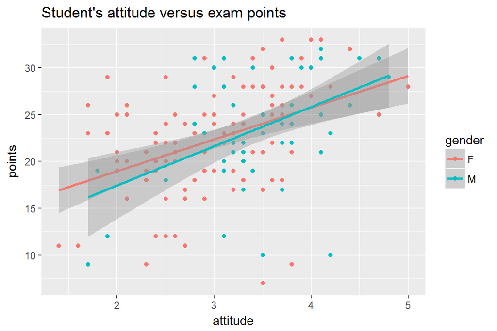

I attempted to make a similar scatter plot out of two other variables in the learning2014 data, for learning’s sake. I decided to choose variables “deep” and “points”, to see if the student’s deep leaning skills are in some kind of connection or loosely said, correlation, with each other.

[figure not shown]

[figure not shown]

From this I concluded, that there seems to be more connection with a students strategic learning skills and their exam points, at least more so than with their deep leaning skills. The regression line in this case, is an ascending line i. e. the slope of the line is positive. This tends to say that the more the student is inclined towads strategic learning, the bigger number of points they seem to score from an exam. However, these are just initial observations, and have little if nothing to do with actual statistical analysis - but based on these ponderings and inclinations I would, as a statistician, try to establish my further work on this notion.

The following illustrates the simple regression between a few of the variables:

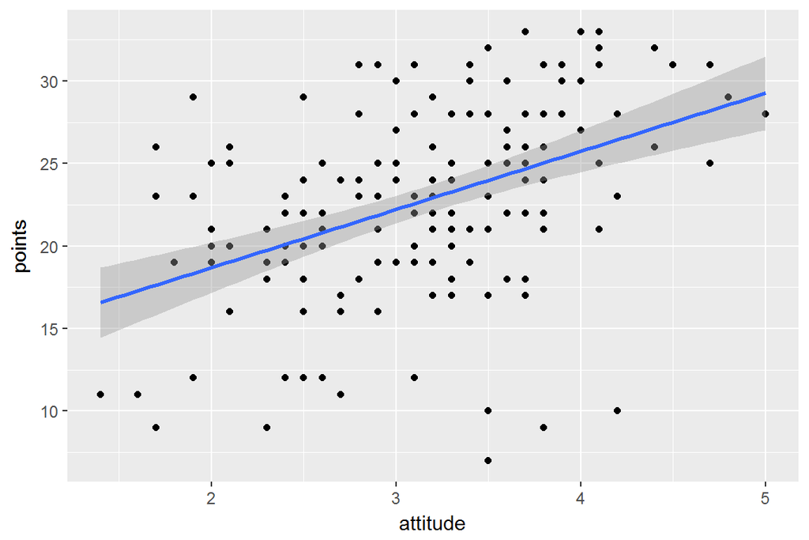

```
##
## Call:
## lm(formula = points ~ attitude, data = learning2014)
##
## Residuals:
##      Min       1Q   Median       3Q      Max
## -16.9763  -3.2119   0.4339   4.1534  10.6645
##
## Coefficients:
##             Estimate Std. Error t value Pr(>|t|)
## (Intercept)  11.6372     1.8303   6.358 1.95e-09 ***
## attitude      3.5255     0.5674   6.214 4.12e-09 ***
## ---
## Signif. codes:  0 '***' 0.001 '**' 0.01 '*' 0.05 '.' 0.1 ' ' 1
##
## Residual standard error: 5.32 on 164 degrees of freedom
## Multiple R-squared:  0.1906, Adjusted R-squared:  0.1856
## F-statistic: 38.61 on 1 and 164 DF,  p-value: 4.119e-09
```

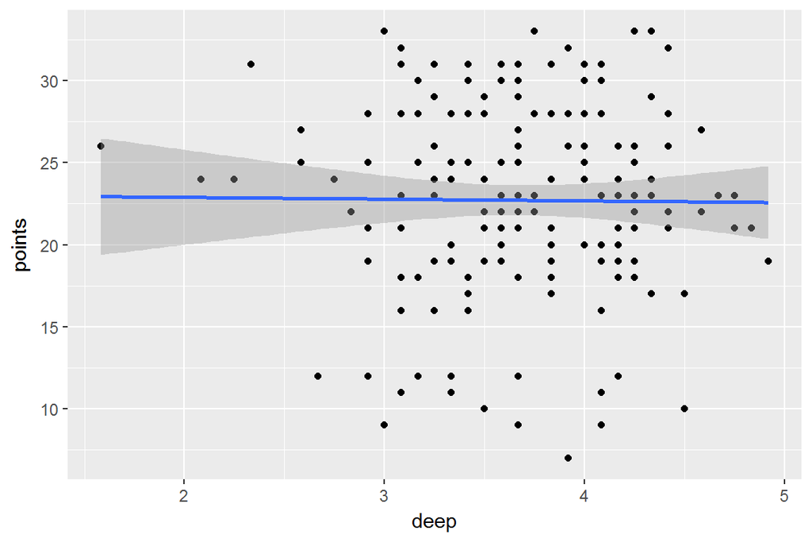

```
##
## Call:
## lm(formula = points ~ deep, data = learning2014)
##
## Residuals:
##      Min       1Q   Median       3Q      Max
## -15.6913  -3.6935   0.2862   4.9957  10.3537
##
## Coefficients:
##             Estimate Std. Error t value Pr(>|t|)
## (Intercept)  23.1141     3.0908   7.478 4.31e-12 ***
## deep         -0.1080     0.8306  -0.130    0.897
## ---
## Signif. codes:  0 '***' 0.001 '**' 0.01 '*' 0.05 '.' 0.1 ' ' 1
##
## Residual standard error: 5.913 on 164 degrees of freedom
## Multiple R-squared:  0.000103,   Adjusted R-squared:  -0.005994
## F-statistic: 0.01689 on 1 and 164 DF,  p-value: 0.8967
```

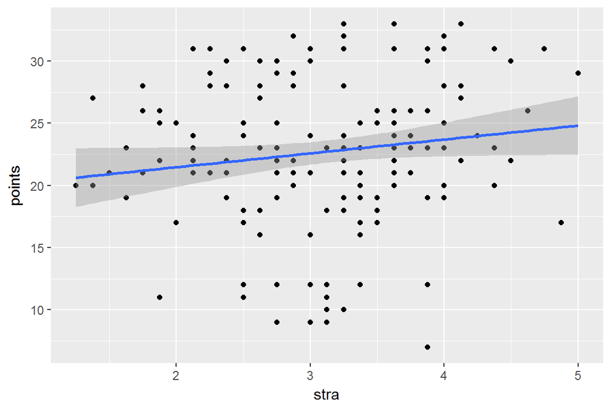

```
##
## Call:
## lm(formula = points ~ stra, data = learning2014)
##
## Residuals:
##      Min       1Q   Median       3Q      Max
## -16.5581  -3.8198   0.1042   4.3024  10.1394
##
## Coefficients:
##             Estimate Std. Error t value Pr(>|t|)
## (Intercept)   19.233      1.897  10.141   <2e-16 ***
## stra           1.116      0.590   1.892   0.0603 .
## ---
## Signif. codes:  0 '***' 0.001 '**' 0.01 '*' 0.05 '.' 0.1 ' ' 1
##
## Residual standard error: 5.849 on 164 degrees of freedom
## Multiple R-squared:  0.02135,    Adjusted R-squared:  0.01538
## F-statistic: 3.578 on 1 and 164 DF,  p-value: 0.06031
```

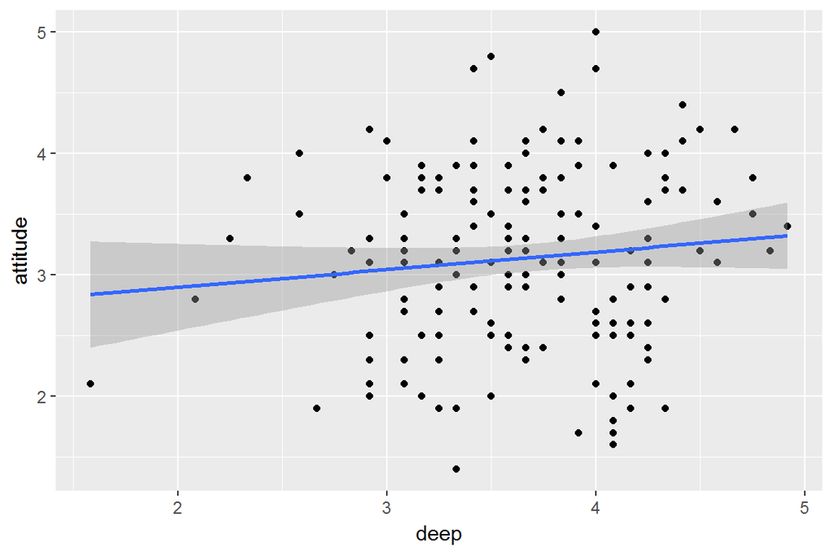

```
##
## Call:
## lm(formula = attitude ~ deep, data = learning2014)
##
## Residuals:
##      Min       1Q   Median       3Q      Max
## -1.69247 -0.55919  0.06358  0.51278  1.81072
##
## Coefficients:
##             Estimate Std. Error t value Pr(>|t|)
## (Intercept)   2.6084     0.3804   6.857 1.36e-10 ***
## deep          0.1452     0.1022   1.420    0.157
## ---
## Signif. codes:  0 '***' 0.001 '**' 0.01 '*' 0.05 '.' 0.1 ' ' 1
##
## Residual standard error: 0.7277 on 164 degrees of freedom
## Multiple R-squared:  0.01215,    Adjusted R-squared:  0.00613
## F-statistic: 2.018 on 1 and 164 DF,  p-value: 0.1574
```

The statistical test related to the parameters is a test for the null-hypothesis, that the beta-parameter in the regression model is actually zero. The p-value indicates the probability of that happening, using this statistical model. The influence of an explanatory variable is statistically significant, if it (in general) is <0,05. The highest value the p-value could take to be statistically at least somewhat significant, is 0,1.

In the above summary-tables, the p-values are for attitude 4.12e-09, which is extremely good, and strictly less than 0,001 which is the best of the signifigance levels. So the influence of attitude to points seems to be significant, and reading from the table, the first estimate, i.e. the beta-parameter, is 3,5255 which indicates a strong positive influence on points. So a good attitude correlates with good points, simply said. The p-value for deep is 0.897, which is not at all a good p-value - it is significantly greater than 0,1, so the influence of deep on points cannot be considered statistically significant. For stra, the p-value is 0.0603, which is pretty good - it is close to 0,05 and definitely less than 0,1.

Attempting to find variables that have statistically significant relationships with the points-variable, I tried many options, one of which was the combination of the variables ‘deep’, ‘stra’, and ‘surf’ as the explanatory variables, which gave puzzling results.

```r
library(ggplot2)
library(GGally)
# create an plot matrix with ggpairs()
ggpairs(learning2014, lower = list(combo = wrap("facethist", bins = 20)))
```

[output not shown]

```r
# create a regression model with multiple explanatory variables
my_model4 <- lm(points ~ deep + stra + surf, data = learning2014)

# print out a summary of the model
summary(my_model4)
```

```
##
## Call:
## lm(formula = points ~ deep + stra + surf, data = learning2014)
##
## Residuals:
##      Min       1Q   Median       3Q      Max
## -15.1235  -3.0737   0.5226   4.2799  10.3229
##
## Coefficients:
##             Estimate Std. Error t value Pr(>|t|)
## (Intercept)  26.9143     5.1169   5.260  4.5e-07 ***
## deep         -0.7443     0.8662  -0.859   0.3915
## stra          0.9878     0.5962   1.657   0.0994 .
## surf         -1.6296     0.9153  -1.780   0.0769 .
## ---
## Signif. codes:  0 '***' 0.001 '**' 0.01 '*' 0.05 '.' 0.1 ' ' 1
##
## Residual standard error: 5.827 on 162 degrees of freedom
## Multiple R-squared:  0.04071,    Adjusted R-squared:  0.02295
## F-statistic: 2.292 on 3 and 162 DF,  p-value: 0.08016
```

Fitting the model, the beta-parameters could be read from the summary-table: for the variable deep the beta-parameter is -0,7443, stra 0,9878 and surf -1,6296. The p value for each of these is, however, greater than 0,05, and for deep the biggest of all. As 0,05 is considered to be the general, known limit for statistical signifigance, the variable deep cannot be considered as an influencing variable for exam points.

To reassign my model, I set the variables ‘attitude’, ‘stra’ and ‘surf’ as the explanatory variables.

```r
library(ggplot2)
library(GGally)
# create an plot matrix with ggpairs()
ggpairs(learning2014, lower = list(combo = wrap("facethist", bins = 20)))
```

[output not shown]

```r
# create a regression model with multiple explanatory variables
my_model4 <- lm(points ~ attitude + stra + surf, data = learning2014)

# print out a summary of the model
summary(my_model4)
```

```
##
## Call:
## lm(formula = points ~ attitude + stra + surf, data = learning2014)
##
## Residuals:
##      Min       1Q   Median       3Q      Max
## -17.1550  -3.4346   0.5156   3.6401  10.8952
##
## Coefficients:
##             Estimate Std. Error t value Pr(>|t|)
## (Intercept)  11.0171     3.6837   2.991  0.00322 **
## attitude      3.3952     0.5741   5.913 1.93e-08 ***
## stra          0.8531     0.5416   1.575  0.11716
## surf         -0.5861     0.8014  -0.731  0.46563
## ---
## Signif. codes:  0 '***' 0.001 '**' 0.01 '*' 0.05 '.' 0.1 ' ' 1
##
## Residual standard error: 5.296 on 162 degrees of freedom
## Multiple R-squared:  0.2074, Adjusted R-squared:  0.1927
## F-statistic: 14.13 on 3 and 162 DF,  p-value: 3.156e-08
```

The summary-table shows the beta-parameters for each of the aforementioned variables, and also that the p-value for ‘attitude’ is 0,0000000193 - which is by all means strictly less than 0,05! Now, with this model, at least for the attitude parameter, the probability of making a Type I -error (discarding error) is very little. For the other parameters, stra and surf, both have >0,1 p-values, which gives the results signifigance level to be quite low and the probability of making the Type I -error (of discaring the null hypothesis) slightly greater.

Fitting the model without the slightly problematic ‘surf’-variable, helps a little, as can be seen from the summary table below:

```
##
## Call:
## lm(formula = points ~ attitude + stra, data = learning2014)
##
## Residuals:
##      Min       1Q   Median       3Q      Max
## -17.6436  -3.3113   0.5575   3.7928  10.9295
##
## Coefficients:
##             Estimate Std. Error t value Pr(>|t|)
## (Intercept)   8.9729     2.3959   3.745  0.00025 ***
## attitude      3.4658     0.5652   6.132 6.31e-09 ***
## stra          0.9137     0.5345   1.709  0.08927 .
## ---
## Signif. codes:  0 '***' 0.001 '**' 0.01 '*' 0.05 '.' 0.1 ' ' 1
##
## Residual standard error: 5.289 on 163 degrees of freedom
## Multiple R-squared:  0.2048, Adjusted R-squared:  0.1951
## F-statistic: 20.99 on 2 and 163 DF,  p-value: 7.734e-09
```

### Interpreting the model parameters

The model parameters can be read from the summary-table. The alpha-parameter indicates, where the regression line intercepts the y-axis. In this case it is 8,9729. The beta-parameter for attitude in this model is 3,4658, which indicates a strong positive influence of attitude on exam points, i. e. the explanatory and target variable. The beta-parameter can be viewed as the slope of the curve which indicates the influence of this variable on the target variable; in this case the line is ascending. In the case of the stra-variable, the beta-parameter is a little bit smaller in value, but still positive, so it can be said that the strategic learning style has a positive influence on exam points - only a bit lesser of an influence than the attitude-variable has.

R-squared is a statistical measure of how close the data are to the fitted regression line. It is also known as ‘the coefficient of determination’, or ‘the coefficient of multiple determination’ for multiple regression, as in this case. By definition, R-squared is the percentage of the response variable variation that is explained by a linear model. In other words: how well the model explains the main variables variation, as opposed to other factors that might affect the main variable. It can be written as

R-squared = Explained variation / total variation

R-squared is always between 0 and 100%: If R-squared is 0% that indicates the model explains none of the variability of the response data around its mean. If R-squared is 100% that indicates that the model explains all the variability of the response data around its mean.

### Graphical model validation

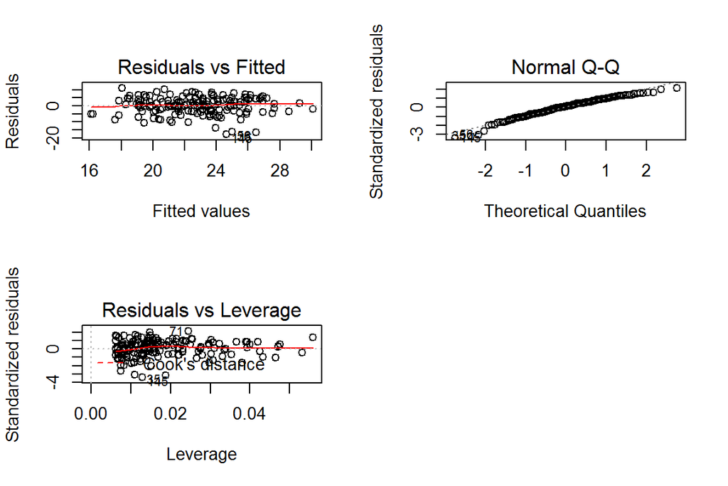

```r
# create a regression model with multiple explanatory variables
my_model4 <- lm(points ~ attitude + stra, data = learning2014)

# draw diagnostic plots using the plot() function. Choose the plots 1, 2 and 5
par(mfrow = c(2,2))
plot(my_model4, which=c(2,5,1))
```

In linear regression the assumptions include that the target variable is assumed to be a linear combination of the explanatory variables - i. e. the fisrt big assumption associated with a linear model is linearity. Generally, it is useful to assume also, that the errors are normally distributed and moreover, with a mean of 0 and a constant variance. This includes also the notion that the errors are not correlated and that the size of an error does not depend on the explanatory variables. There are a number of graphical ways to explore these assumptions, for example:

### The Residuals vs. Fitted values -plot

The Residuals vs. Fitted values -plot explores the constant variance assumption of the errors in the model, in other words the assumption that there should be no or close to none dependency between the errors and the explanatory variables. The simple plot shows residuals and model predictions, and if there seems to be any pattern in the plot, one could conclude that there is some dependency and the variance of the errors is not constant.

### The Normal QQ-plot

The Normal QQ-plot is a plot of the residuals that can be used to explore the assumption of the normality of the errors in the model. In the Normal QQ-plot of the model in question, the points of the plot seem to fall pretty nicely on the curve, and nothing seems to deviate out of the line. Consequently, according to this graphical model validation plot, the model’s errors are (at least close to being) normally distributed and the normality assumption is correct.

### The Residual vs. Leverage -plot

The Residual vs. Leverage -plot measures, how much impact a single observation has on the model. By analyzing the plot, any observations that have a high impact on the model, can be identified. The model of the two explanatory variables affecting the points-variable, we can see that the scale of the Leverage-plot is not very wide - only from 0 to 0,05. This indicates, that no observation is stranded outside the plot, and if there are observations in the fringes of the plot, the distance to other observations is not so big. Also, all the observations seem to fall in the plot quite evenly, which in itself indicates that there are no single observations having unusually high impact on the model. So the linearity assumption can be said to be correct in this model.

# Week 3: logistic regression

### A look into the data set : Student alcohol consumption

The names of the variables can be seen from the R-print below, produced with the colnames()-function.

```
##  [1] "X1"         "school"     "sex"        "age"        "address"
##  [6] "famsize"    "Pstatus"    "Medu"       "Fedu"       "Mjob"
## [11] "Fjob"       "reason"     "nursery"    "internet"   "guardian"
## [16] "traveltime" "studytime"  "failures"   "schoolsup"  "famsup"
## [21] "paid"       "activities" "higher"     "romantic"   "famrel"
## [26] "freetime"   "goout"      "Dalc"       "Walc"       "health"
## [31] "absences"   "G1"         "G2"         "G3"         "alc_use"
## [36] "high_use"
```

## Relationships between the variables: hypothesis and exploration

My hypothesis is that high/low alcohol consumption is n connection to the “absences” = “number of school absences”, " famrel" = “quality of family relationships”, " studytime" = “weekly study time” and “goout” = “going out with friends” variables.

I presume that a high number of absences correlates somehow with high alcohol use, and a low number of such absences is in connection with a low usage of alcohol and as for family, that bad family relationships correlate with high alcohol consumption and respectively, good family relationships might be in connection with a lower consumption of alcohol. I also predict that a lot of time spent studying would contribute to a lower amount of consumed alcohol and going out with friends a lot would correlate with a higher usage, and in turn, not much free time and not going out much with friends would be a contributor to not using that much alcohol.

First, I created cross tabulations of the variables in relation to the high_use-variable.

```
##         absences
## high_use  0  1  2  3  4  5  6  7  8  9 10 11 12 13 14 16 17 18 19 20 21 26
##    FALSE 52 38 42 33 24 16 16  9 14  6  5  2  4  1  1  0  0  1  0  2  1  0
##    TRUE  13 13 16  8 12  6  5  3  6  6  2  4  4  1  6  1  1  1  1  0  1  1
##         absences
## high_use 27 29 44 45
##    FALSE  0  0  0  1
##    TRUE   1  1  1  0
```

```
##         famrel
## high_use   1   2   3   4   5
##    FALSE   6  10  39 135  78
##    TRUE    2   9  25  54  24
```

```
##         studytime
## high_use   1   2   3   4
##    FALSE  58 135  52  23
##    TRUE   42  60   8   4
```

```
##         goout
## high_use   1   2   3   4   5
##    FALSE  19  84 103  41  21
##    TRUE    3  16  23  40  32
```

I decided to make the cross tabulations with high_use instead of the whole alc_use- variable, since it seemed more clear and straghtforward to interpret the tables using that approach. It can be seen from the cross tabulations that when high_use gets the value “FALSE”, i.e. alcohol consumption is less or equal to 2, there were more observations in the lower part of the absence range, i. e. there were 0-10 absences in case of one student. In case of high alcohol use, there were not as many students who had 0-10 absences, as there were those who didn’t qualify for high use. In the high use case, there were also some observations in the high end of the absence scale, i.e. some students who had even 18 or 19 absences, but the diffeence to the number of observations in that end for the low alcohol use is only that there is 1 student with 18 absences present in the data.

For those students, whose family relationships were good, such as values 3-5, got a high_use value of “FALSE”, and didn’t qualify for high alcohol use. It could be further inspected, whether the correlation between good family relations and lower alcohol use is actually true, but looking at this table good family relations do seem to matter.

Looking at the studytime table, the students whose alcohol use was high, also used less time studying - there were more observations in the 1-2 end of the scale in case of the high_use TRUE value than there were in the 2-4 end of the scale. So those students who used higher amounts of alcohol also studied less, according to this initial observation from the cross tabulation.

Also those students, who didn’t go out so much didn’t seem to get high_use = TRUE -values as often as those whose going out variable got values 3-5. So going out more seems to be in connection with high alcohol usage based on the tabulation.

To further visualize these ponderings, I used ggplot, geom_bar and geom_boxplot to draw some pictures about the distributions of these variables, and in addition, a bar plot of each variable using the pipe-method introduced in the DataCamp-exercise.

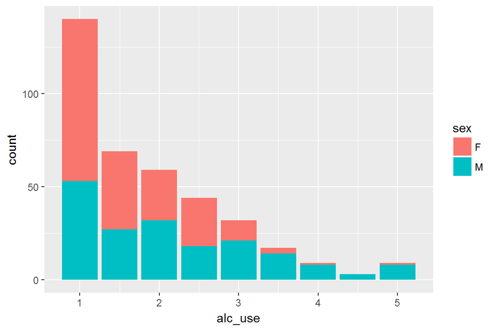

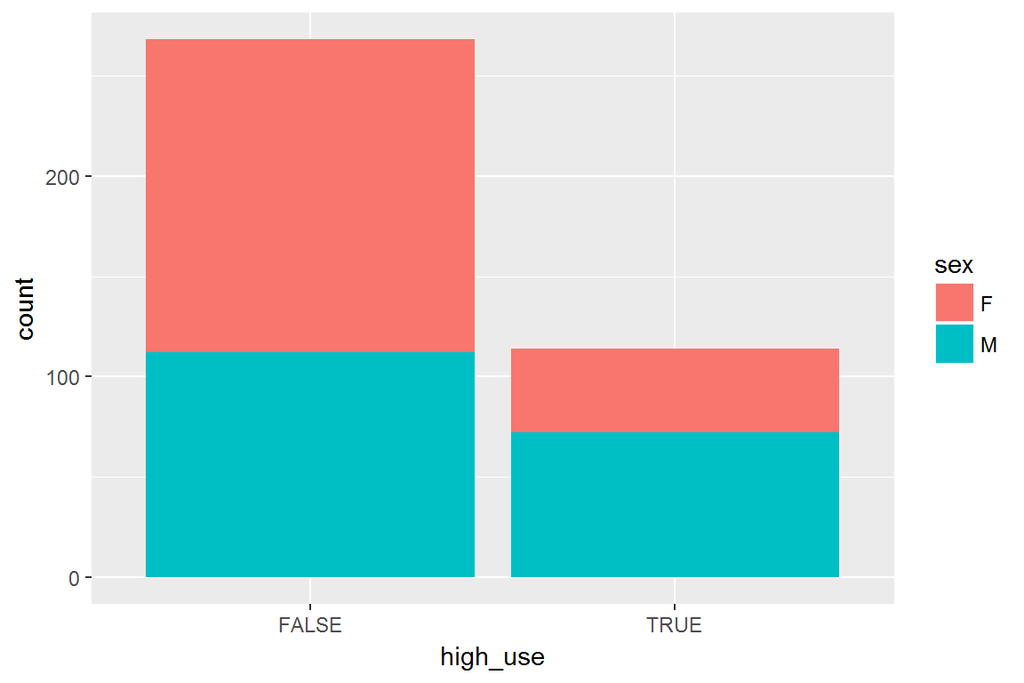

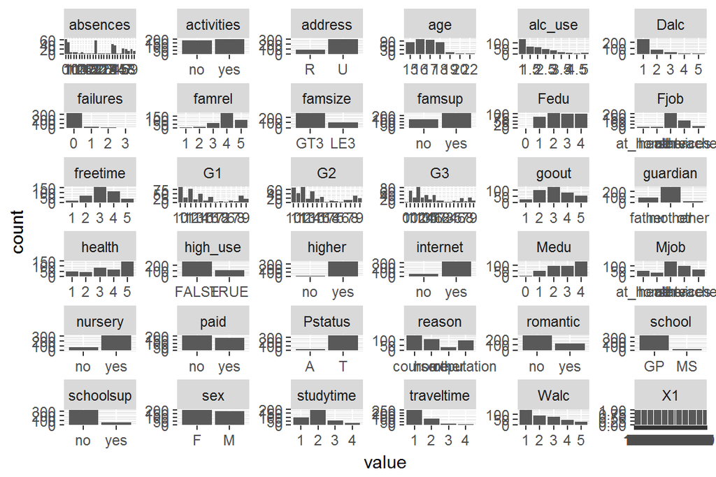

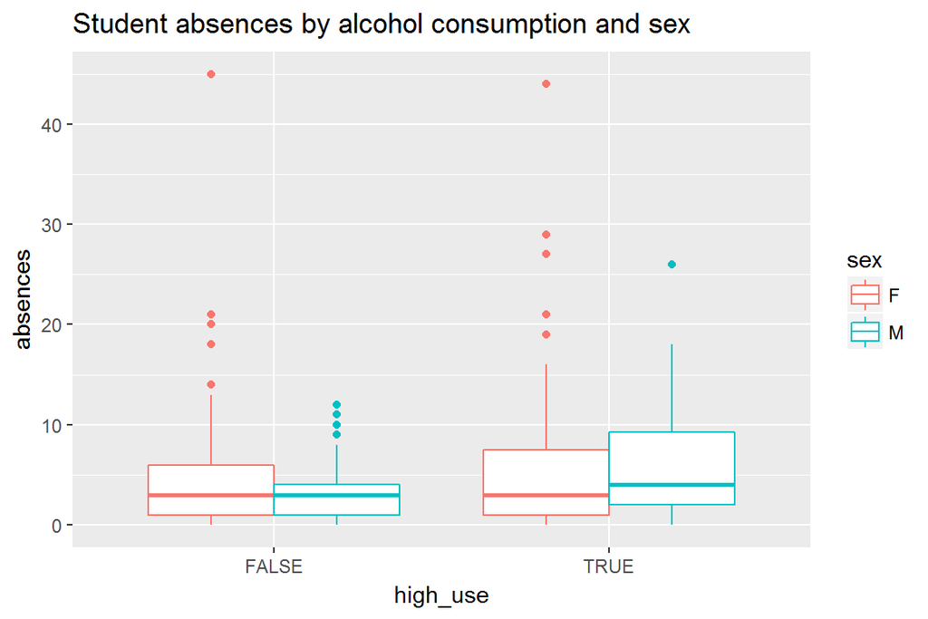

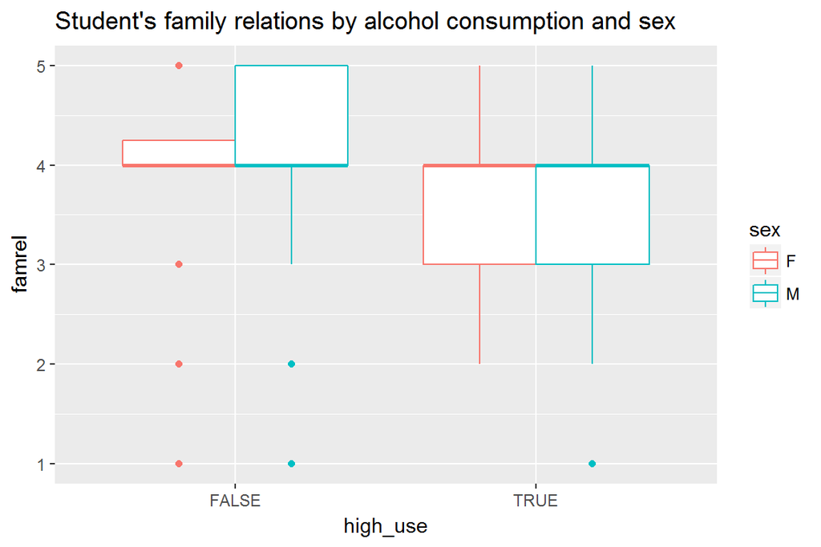

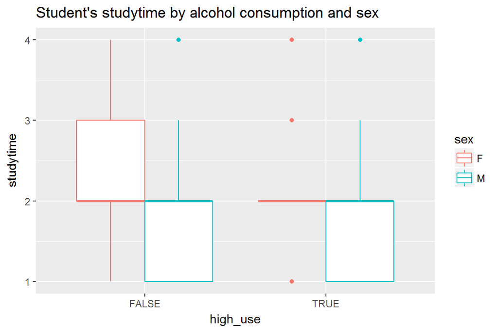

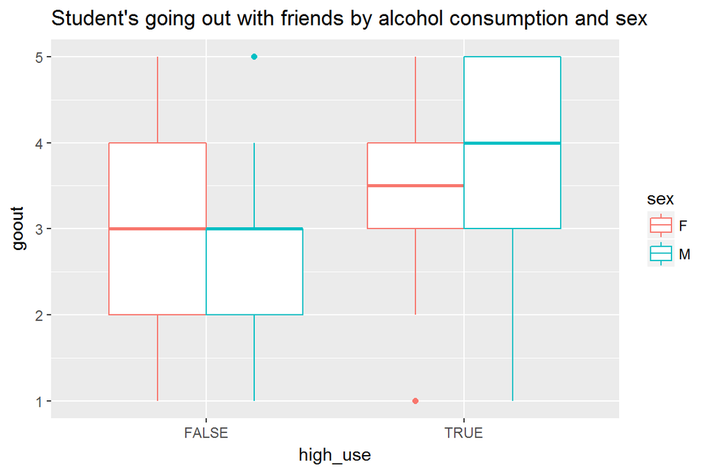

The bar plots of all the variables are pretty straightforwad to interpret; they show the distribution of the values the variable takes - the frequency of a given value or an interval of values being depicted as a bar. From the bar plots of overall alcohol use and high alcohol use it can be concluded that the higher end of the scale for alc_use is less frequent, i.e. the students in this data answered more often from the 1-3 than 4-5 part of the scale. Low use seems more common among females than males, who were more frequently featured in the 4 and 5 bars of the bar plot. The high_use bar plot clarifies this observation: it clearly depicts the proportion of female in the high_use = “FALSE” value being significantly larger than that of male’s, and in turn the quantity of men whose high_use = “TRUE” is larger than that of women.

In the overall bar plot picture, for example the absence variable takes values from each of the ends of the scale, more in the lower part and in the middle than in the high numbers. For studytime the value 2 is the most common, followed by 1, so the students used little time studying more often than “a lot of time”, and 4 was clearly the least common value. The goout-variable’s barplot seems quite normal, the most values were 3 and the ends of the scale were less frequent. As for family relationships, the value 4 was most common and right after that the value 5, which gives an impression of quite good family relations in general for the students of this data.

The box plots illustrate the 25th, 50th and 75th percentiles which are shown as “the box” in the box plot, and the lines in the fringes being the typical range. In the box plot there are also the outliers outside the lines, which are shown as discrete spots or lines.

As Tuomo Nieminen in the instruction in the Data Camp -exercise states “The whiskers” or lines that extend from the box are computed so that they extend to reach a data point that is no more than 1.5*IQR away from the box. The IQR, or the inter quartile range is defined as the 25th percentile distracted from the 75th percentile.

In first one of these box plots one can see that the typical range of absences versus high use is slightly wider and slightly upper in the scale when high use is TRUE than when it is false. Also the 25th to 75th percentile part, i.e. the box, is bigger. This goes well with the observations made from the cross tabulation before. Also in good connection with the conclusions from the cross tabulations is the family relations box plot, where the range is upper in the scale in case of low alcohol consumption, which means that in that case there were more values that indicate good family relations in case of low consumption of alcohol. The studytime variable’s box plot shows that the range of the observations is definitely in the lower part, i. e. in the less time spent studing part of the scale, when the alcohol consumption is high, and on the other hand, the range of going out is higher on the scale when alcohol consumption is high than when it is low.

## The logistic regression model

### The summary of the model and interpretation of the coefficients

```
##
## Call:
## glm(formula = high_use ~ absences + famrel + studytime + goout,
##     family = "binomial", data = alc)
##
## Deviance Residuals:
##     Min       1Q   Median       3Q      Max
## -1.8701  -0.7738  -0.5019   0.8042   2.5416
##
## Coefficients:
##             Estimate Std. Error z value Pr(>|z|)
## (Intercept) -1.28606    0.70957  -1.812  0.06992 .
## absences     0.06753    0.02175   3.104  0.00191 **
## famrel      -0.33699    0.13681  -2.463  0.01377 *
## studytime   -0.55089    0.16789  -3.281  0.00103 **
## goout        0.75953    0.12041   6.308 2.82e-10 ***
## ---
## Signif. codes:  0 '***' 0.001 '**' 0.01 '*' 0.05 '.' 0.1 ' ' 1
##
## (Dispersion parameter for binomial family taken to be 1)
##
##     Null deviance: 465.68  on 381  degrees of freedom
## Residual deviance: 384.07  on 377  degrees of freedom
## AIC: 394.07
##
## Number of Fisher Scoring iterations: 4
```

```
## (Intercept)    absences      famrel   studytime       goout
## -1.28606058  0.06753071 -0.33699130 -0.55089391  0.75953025
```

```
##                    OR      2.5 %    97.5 %
## (Intercept) 0.2763573 0.06723596 1.0961732
## absences    1.0698631 1.02591583 1.1187950
## famrel      0.7139151 0.54460646 0.9331198
## studytime   0.5764343 0.41040872 0.7941804
## goout       2.1372720 1.69853389 2.7261579
```

The summary of the fitted model with high_use as the target variable and absences, famrel, studytime and goout as the explanatory variables. It seems that all of the variables above test statistically significant in this logistic regression model, in case of the null hypothesis that the parameters for each variable are actually 0. The statistical significance levels can be read from the table similarly as in last weeks exercise. If the odds ratio equals to 1, there is no statistical connection between the target variable and the explanatory variable in question. However, hypothesis tests for the odds ratio can not used to determine statistical significance of the association between the variables in the model, like last week. Instead, confidence intervals of OR are constructed and used to determine whether or not the association is statistically significant. The confidence interval for an odds ratio has the same general formula as any confidence interval: Point Estimate + Confidence Coefficient multiplied by Standard Error, and Point Estimate - Confidence Coefficient multiplied by Standard Error. The difference is that the confidence interval of the odds ratio is calculated on a natural logarithm scale and then converted back to the original scale, whereas this is not needed in the case of a population mean, for example. The statistical signigficance is then determined as follows: if the 95% Confidence Interval does not contain the value 1.0, the association is statistically significant at alpha = 0,05.

The exponents of the printed coefficients can be interpreted as the odd ratios between a unit change in the corresponding explanatory variable, versus no change in that explanatory variable. To illustrate this with an example: if there is a unit change in absences the student is 1,07 times more likely to be inclined towards high-alcohol usage, which tends to say that high number of absences tells something about alcohol usage and the two variables are possibly in some sort of statistical relationship, also reassuring that my initial hypothesis regarding the higer number of absences and high use of alcohol being in positive connection.

In turn, if there’s a unit change in family relations, the person is only 0,71 times more likely to incline towards high usage, so if there is no change in famrel, the person is 1/0,71=1,41 times more likely to high use. Gathering from that the hypothesis on bad family relations being connected to higher use of alcohol seems to be legit, as no change in the explanatory variable gives the result of the student being more likely to use more alcohol. In this case there’s also a possibility of a statistically significant relationship between the explanatory and the target variable.

As for how the students spend their spare time, for time spent studying the exponent of the coefficient i.e. the odds ratio is only 0.57 which means that if there’s no change in the studytime variable the student is even 1/0,57 = 1,75 times more likely to high use. It seems that my hypothesis with regards to this variable and its connection with high use is also more in the right than in the wrong. Consequently, going out with friends and high use seem to have the strongest connection: a unit change in the variable goout means that the student is 2,14 times more likely to use a lot of alcohol, which is the largest number in the exponents of the coefficients table. It would mean that the hypothesis is correct in light of this initial exploration and this paticular model, and also goes well together with the intuition that the more time spend hanging out with a group of friends the more likely the student is to use alcohol.

From the above coefficient/confidence interval table it can also be seen that none of the confidence intervals contain the value 1,0, which indicates that the above statements considering the explanatory variables are somewhat true and their relationship to the target variable are statistically significant at confidence level 0,05.

```r
# fit the model
m <- glm(high_use ~ absences + famrel + studytime + goout, data = alc, family = "binomial")

# predict() the probability of high_use
probabilities <- predict(m, type = "response")

# add the predicted probabilities to 'alc'
alc <- mutate(alc, probability = probabilities)

# use the probabilities to make a prediction of high_use
alc <- mutate(alc, prediction = (probability > 0.5))

# tabulate the target variable versus the predictions
table(high_use = alc$high_use, prediction = alc$prediction)
```

```
##         prediction
## high_use FALSE TRUE
##    FALSE   242   26
##    TRUE     65   49
```

The predict() function can be used to make predictions with the model. By using predict() on the model object and mutating the alc data again by adding a column ‘probability’ with the predicted probabilities, adding a column ‘prediction’ which is true if the value of ‘probability’ is greater than 0.5, I produced a confusion matrix or the cross table above. It shows how good the model is in terms of predicting: it can be seen that when high_use is false, 242 times the prediction with this model is also false and only 26 times actually true (when the prediction would be wrong), and when high_use is true, the prediction is false in 65 cases and true in 49 cases. This is a little bit confusing, and gives the impression that predictions in case of the actual value being true are not accurate based on this model, but when the actual calue is false the predictions tend to be more accurate than not.

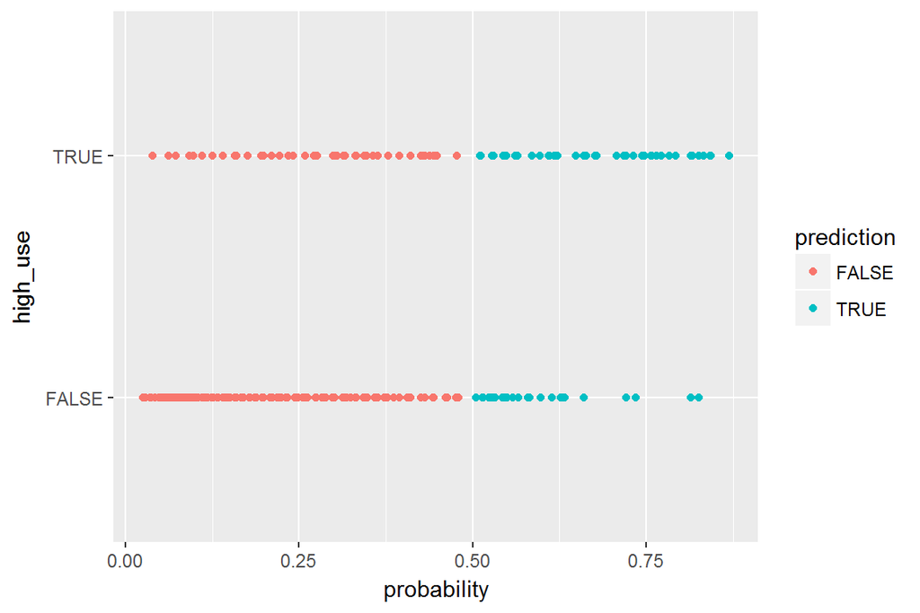

```r
# access dplyr and ggplot2
library(dplyr); library(ggplot2)

# initialize a plot of 'high_use' versus 'probability' in 'alc'
g <- ggplot(alc, aes(x = probability, y = high_use, col = prediction))

# define the geom as points and draw the plot
g + geom_point()
```

```r
# tabulate the target variable versus the predictions
table(high_use = alc$high_use, prediction = alc$prediction) %>% prop.table %>% addmargins
```

```
##         prediction
## high_use      FALSE       TRUE        Sum
##    FALSE 0.63350785 0.06806283 0.70157068
##    TRUE  0.17015707 0.12827225 0.29842932
##    Sum   0.80366492 0.19633508 1.00000000
```

By drawing the plot of actual values vs. predictions and the probability cross table of actual values vs. predictions, the proportions of the false and true predictions are more visually comprehensible. In the case of binary classification the wellness of the model can be determined by looking at its accuracy, which means the average number of observations that are correctly classified. Logistic regression is a classification method, in which the aim is to minimize the number of wrongly classified observations. The notion of penalty or loss function for the logistic regression describes the mean of the wrongly classified observations or in this case, students. The less penalty, the better the model.

First step is to define the loss function as the average of the wrong predictions.

```r
# define a loss function (mean prediction error)
loss_func <- function(class, prob) {
  n_wrong <- abs(class - prob) > 0.5
  mean(n_wrong)
}

loss_func(class = alc$high_use, prob = alc$probability)
```

```
## [1] 0.2382199
```

This model has an average of 0,238 wrong predictions or inaccurately classified individuals, which is also called the training error. The value is quite good, considering the model setting, since it is significantly less than 0,5. Surely it could be less for the model to be extremely good - on average, 1 in 4 predictions is wrong - but at this stage, it is not an alarming number, since roughly over 75 percent of the predictions are correct. This model is much better than, for example, tossing a coin to predict the values of the variables.

Now, using the 10-fold cross validation my model gets the following values:

```
## [1] 0.2382199
```

```
## [1] 382
```

```
## [1] 0.2408377
```

# Week 4: Clustering and classification

### A look into the data set : The Boston data

The Boston dataset, more formally called “Housing Values in Suburbs of Boston”, is a dataset that can be found already installed within the MASS-package in R. The data and its variables can be explored from the tables below, produced by the str() and summary() functions of R. The dimensions of the Boston data are 506 rows and 14 columns, i. e. 506 observations and 14 variables, the type of which is either numeric or integer. In other words there are no character or factor type variables in this dataset. The names of the variables can be seen below, produced with the colnames()-function.

The data has variables measuring different aspects of housing and living in the city of Boston, including variables such as “rad” described as the index of accessibility to radial highways and “crim” that is the per capita crime rate by town. Of these the latter will be explored further in this week’s exercise.

More information regarding the Boston data can be found in this [link](https://stat.ethz.ch/R-manual/R-devel/library/MASS/html/Boston.html).

```
##  [1] "crim"    "zn"      "indus"   "chas"    "nox"     "rm"      "age"
##  [8] "dis"     "rad"     "tax"     "ptratio" "black"   "lstat"   "medv"
```

```
## [1] 506  14
```

```
## 'data.frame':    506 obs. of  14 variables:
##  $ crim   : num  0.00632 0.02731 0.02729 0.03237 0.06905 ...
##  $ zn     : num  18 0 0 0 0 0 12.5 12.5 12.5 12.5 ...
##  $ indus  : num  2.31 7.07 7.07 2.18 2.18 2.18 7.87 7.87 7.87 7.87 ...
##  $ chas   : int  0 0 0 0 0 0 0 0 0 0 ...
##  $ nox    : num  0.538 0.469 0.469 0.458 0.458 0.458 0.524 0.524 0.524 0.524 ...
##  $ rm     : num  6.58 6.42 7.18 7 7.15 ...
##  $ age    : num  65.2 78.9 61.1 45.8 54.2 58.7 66.6 96.1 100 85.9 ...
##  $ dis    : num  4.09 4.97 4.97 6.06 6.06 ...
##  $ rad    : int  1 2 2 3 3 3 5 5 5 5 ...
##  $ tax    : num  296 242 242 222 222 222 311 311 311 311 ...
##  $ ptratio: num  15.3 17.8 17.8 18.7 18.7 18.7 15.2 15.2 15.2 15.2 ...
##  $ black  : num  397 397 393 395 397 ...
##  $ lstat  : num  4.98 9.14 4.03 2.94 5.33 ...
##  $ medv   : num  24 21.6 34.7 33.4 36.2 28.7 22.9 27.1 16.5 18.9 ...
```

```
##       crim                zn             indus            chas
##  Min.   : 0.00632   Min.   :  0.00   Min.   : 0.46   Min.   :0.00000
##  1st Qu.: 0.08204   1st Qu.:  0.00   1st Qu.: 5.19   1st Qu.:0.00000
##  Median : 0.25651   Median :  0.00   Median : 9.69   Median :0.00000
##  Mean   : 3.61352   Mean   : 11.36   Mean   :11.14   Mean   :0.06917
##  3rd Qu.: 3.67708   3rd Qu.: 12.50   3rd Qu.:18.10   3rd Qu.:0.00000
##  Max.   :88.97620   Max.   :100.00   Max.   :27.74   Max.   :1.00000
##       nox               rm             age              dis
##  Min.   :0.3850   Min.   :3.561   Min.   :  2.90   Min.   : 1.130
##  1st Qu.:0.4490   1st Qu.:5.886   1st Qu.: 45.02   1st Qu.: 2.100
##  Median :0.5380   Median :6.208   Median : 77.50   Median : 3.207
##  Mean   :0.5547   Mean   :6.285   Mean   : 68.57   Mean   : 3.795
##  3rd Qu.:0.6240   3rd Qu.:6.623   3rd Qu.: 94.08   3rd Qu.: 5.188
##  Max.   :0.8710   Max.   :8.780   Max.   :100.00   Max.   :12.127
##       rad              tax           ptratio          black
##  Min.   : 1.000   Min.   :187.0   Min.   :12.60   Min.   :  0.32
##  1st Qu.: 4.000   1st Qu.:279.0   1st Qu.:17.40   1st Qu.:375.38
##  Median : 5.000   Median :330.0   Median :19.05   Median :391.44
##  Mean   : 9.549   Mean   :408.2   Mean   :18.46   Mean   :356.67
##  3rd Qu.:24.000   3rd Qu.:666.0   3rd Qu.:20.20   3rd Qu.:396.23
##  Max.   :24.000   Max.   :711.0   Max.   :22.00   Max.   :396.90
##      lstat            medv
##  Min.   : 1.73   Min.   : 5.00
##  1st Qu.: 6.95   1st Qu.:17.02
##  Median :11.36   Median :21.20
##  Mean   :12.65   Mean   :22.53
##  3rd Qu.:16.95   3rd Qu.:25.00
##  Max.   :37.97   Max.   :50.00
```

First, I wanted to see how the crime rate is affected by different variables. To do that, I created boxplots of some of the variables in relation to the crime rate -variable “crim”. I am not sure how useful these explorations are, however I decided to engage in them as I thought it would at least be good practice, if not anything else. Consequently, I created a new variable “high_crim” by mutating the Boston data and setting high_crim to be true when the crim-variable gets values from (roughly) above the mean (3.6…). The variables I chose are those that in my opinion might have some kind of connection or relationship with the crime rate, the variables being the following:

“lstat” = lower status of the population (percent) “rad” = index of accessibility to radial highways.

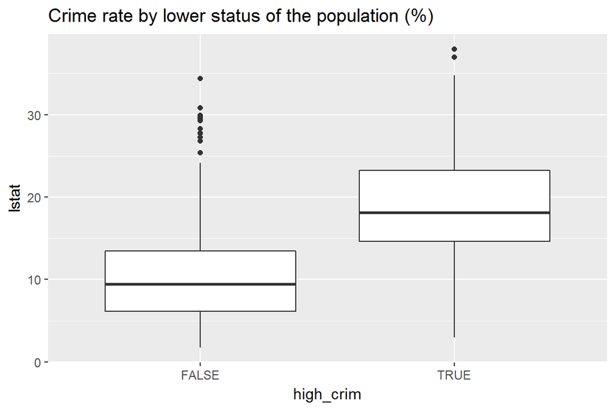

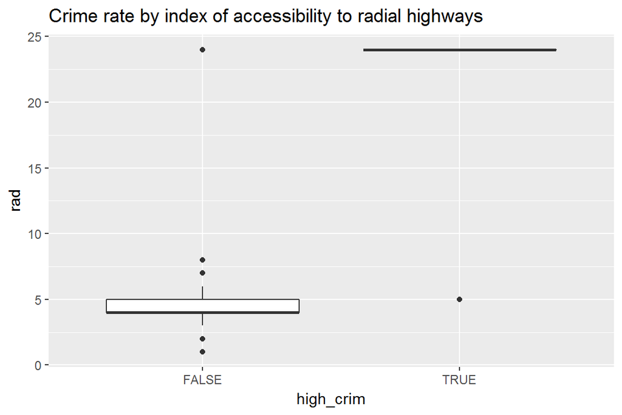

Judging from the first box plot it seems that when the percent of population classified as lower is higher, the high_crime-variable gets the value TRUE. This essentially means that when there are more “lower class” -people in the neighbourhood or town, also the crime rate is elevated. This confirms tosome extent my initial hypothesis of these variables having some kind of connection, and also goes along with the intuition that low-class neighbourhoods have a higher crime rate than those inhabitated by people of the wealthier upper or mid-class. The second box plot shows that higher crime rate is in connection to the access to radial highways, as the high_crime variable gets the value TRUE for high values of the access to highways -variable. One could think that areas in the midst of or in the crossroads of big highways would have more traffic, more people and more gangs etc., i. e. more criminal activity would take place in that kind of environment.

To look at the correlation and relationships between all the variables in general, I created plots and correlation matrices with pairs()- and cor()-functions. Below the correlation matrix is also visualized with the corrplot()-function.

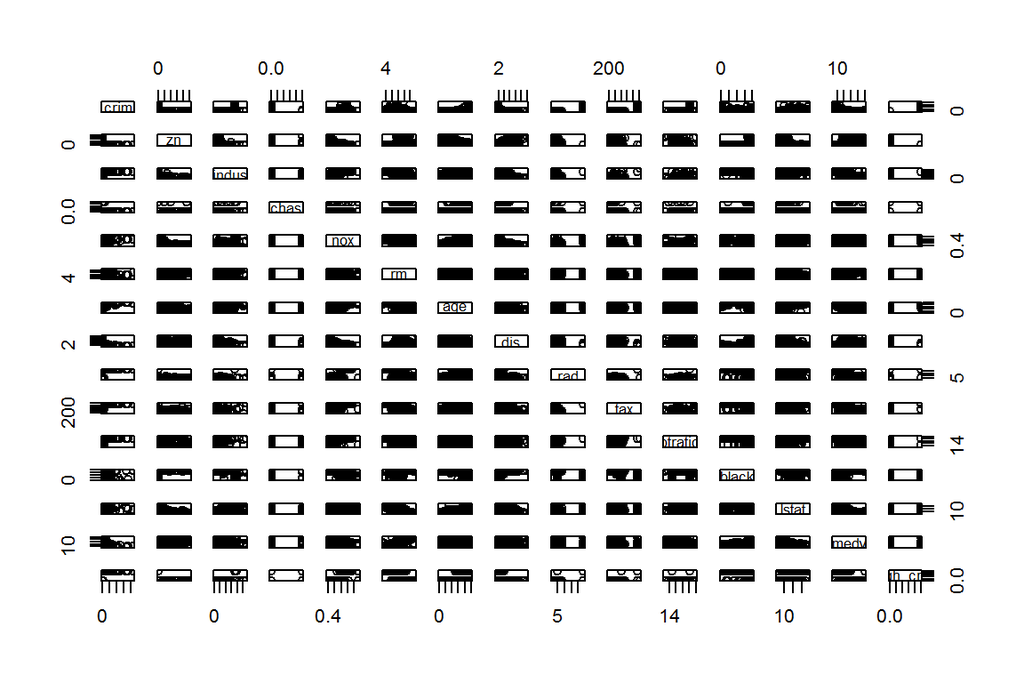

```
##            crim    zn indus  chas   nox    rm   age   dis   rad   tax
## crim       1.00 -0.20  0.41 -0.06  0.42 -0.22  0.35 -0.38  0.63  0.58
## zn        -0.20  1.00 -0.53 -0.04 -0.52  0.31 -0.57  0.66 -0.31 -0.31
## indus      0.41 -0.53  1.00  0.06  0.76 -0.39  0.64 -0.71  0.60  0.72
## chas      -0.06 -0.04  0.06  1.00  0.09  0.09  0.09 -0.10 -0.01 -0.04
## nox        0.42 -0.52  0.76  0.09  1.00 -0.30  0.73 -0.77  0.61  0.67
## rm        -0.22  0.31 -0.39  0.09 -0.30  1.00 -0.24  0.21 -0.21 -0.29
## age        0.35 -0.57  0.64  0.09  0.73 -0.24  1.00 -0.75  0.46  0.51
## dis       -0.38  0.66 -0.71 -0.10 -0.77  0.21 -0.75  1.00 -0.49 -0.53
## rad        0.63 -0.31  0.60 -0.01  0.61 -0.21  0.46 -0.49  1.00  0.91
## tax        0.58 -0.31  0.72 -0.04  0.67 -0.29  0.51 -0.53  0.91  1.00
## ptratio    0.29 -0.39  0.38 -0.12  0.19 -0.36  0.26 -0.23  0.46  0.46
## black     -0.39  0.18 -0.36  0.05 -0.38  0.13 -0.27  0.29 -0.44 -0.44
## lstat      0.46 -0.41  0.60 -0.05  0.59 -0.61  0.60 -0.50  0.49  0.54
## medv      -0.39  0.36 -0.48  0.18 -0.43  0.70 -0.38  0.25 -0.38 -0.47
## high_crim  0.64 -0.28  0.59 -0.03  0.61 -0.24  0.47 -0.49  0.96  0.88
##           ptratio black lstat  medv high_crim
## crim         0.29 -0.39  0.46 -0.39      0.64
## zn          -0.39  0.18 -0.41  0.36     -0.28
## indus        0.38 -0.36  0.60 -0.48      0.59
## chas        -0.12  0.05 -0.05  0.18     -0.03
## nox          0.19 -0.38  0.59 -0.43      0.61
## rm          -0.36  0.13 -0.61  0.70     -0.24
## age          0.26 -0.27  0.60 -0.38      0.47
## dis         -0.23  0.29 -0.50  0.25     -0.49
## rad          0.46 -0.44  0.49 -0.38      0.96
## tax          0.46 -0.44  0.54 -0.47      0.88
## ptratio      1.00 -0.18  0.37 -0.51      0.46
## black       -0.18  1.00 -0.37  0.33     -0.45
## lstat        0.37 -0.37  1.00 -0.74      0.51
## medv        -0.51  0.33 -0.74  1.00     -0.40
## high_crim    0.46 -0.45  0.51 -0.40      1.00
```

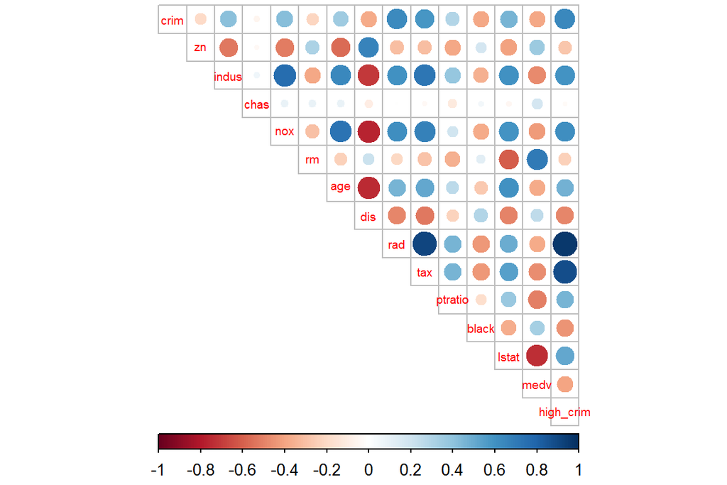

The picture produced with the pairs()-function is a bit hard to interpret, ut it provides a glimpse onto the relationships between all the variables in the dataset. For a more thorough look at the relationships one could consider the correlation matrix and its very useful visualization. From the aforementioned two we can see that the variable rad of which I created the boxplot with high_crime earlier, has a quite strong positive correlation with crime, the value of it being 0.63. It is depicted in the vizualization with a rather large and opaque, blue dot. So in other words, when the rad-variable increases, so does the crime rate. We can also notice that the lstat-variable has also a somewhat significant (0.46) positive correlation with the crime rate variable, which is shown as a slightly lighter blue dot in the visualization. So high values for lstat mean high values for crim.

Also the tax and nox variables (full-value property-tax rate per $10,000 and nitrogen oxides concentration (parts per 10 million)) have a positive correlation with crime rate, 0.58 and 0.42 respectively. Furthermore, tax rate correlates positively with rad (access to highways) so the more accessible the city/are the more crime it has (over-simplifiedly put). The med variable or the median value of owner-occupied homes in $1000s on the other hand correlated negatively with lstat, or the lower status of the population, the value being -0.74. Intuitively, this makes sense since lower class population more probably doesn’t own high value homes if it owns homes at all. The negative correlation is denoted as red colour in the visualization, and accordingly, the dot between the medv- and lstat-variables is rather big and red.

According to the instructions, I scaled the Boston dataset and changed the object’s class to be data frame. The scaling needs to be done in order to perform Linear Discriminant Analysis on the data, as the assumptions of the analysis are that the variables are normally distributed and have the same variance. In order to ger this result, the scale()-function scales the variables by distracting the mean and dividing the result by standard deviation, resulting in the means of the variables to be exactly equal to zero, as can be seen from the summary. In that way the variables are centered and standardized, i. e. more easily comparable to each other and more calculations can be done based on the relations between the variables as they’re measured on the same range.

```r
# center and standardize variables
boston_scaled <- scale(Boston)

# summaries of the scaled variables
summary(boston_scaled)
```

```
##       crim                 zn               indus
##  Min.   :-0.419367   Min.   :-0.48724   Min.   :-1.5563
##  1st Qu.:-0.410563   1st Qu.:-0.48724   1st Qu.:-0.8668
##  Median :-0.390280   Median :-0.48724   Median :-0.2109
##  Mean   : 0.000000   Mean   : 0.00000   Mean   : 0.0000
##  3rd Qu.: 0.007389   3rd Qu.: 0.04872   3rd Qu.: 1.0150
##  Max.   : 9.924110   Max.   : 3.80047   Max.   : 2.4202
##       chas              nox                rm               age
##  Min.   :-0.2723   Min.   :-1.4644   Min.   :-3.8764   Min.   :-2.3331
##  1st Qu.:-0.2723   1st Qu.:-0.9121   1st Qu.:-0.5681   1st Qu.:-0.8366
##  Median :-0.2723   Median :-0.1441   Median :-0.1084   Median : 0.3171
##  Mean   : 0.0000   Mean   : 0.0000   Mean   : 0.0000   Mean   : 0.0000
##  3rd Qu.:-0.2723   3rd Qu.: 0.5981   3rd Qu.: 0.4823   3rd Qu.: 0.9059
##  Max.   : 3.6648   Max.   : 2.7296   Max.   : 3.5515   Max.   : 1.1164
##       dis               rad               tax             ptratio
##  Min.   :-1.2658   Min.   :-0.9819   Min.   :-1.3127   Min.   :-2.7047
##  1st Qu.:-0.8049   1st Qu.:-0.6373   1st Qu.:-0.7668   1st Qu.:-0.4876
##  Median :-0.2790   Median :-0.5225   Median :-0.4642   Median : 0.2746
##  Mean   : 0.0000   Mean   : 0.0000   Mean   : 0.0000   Mean   : 0.0000
##  3rd Qu.: 0.6617   3rd Qu.: 1.6596   3rd Qu.: 1.5294   3rd Qu.: 0.8058
##  Max.   : 3.9566   Max.   : 1.6596   Max.   : 1.7964   Max.   : 1.6372
##      black             lstat              medv           high_crim
##  Min.   :-3.9033   Min.   :-1.5296   Min.   :-1.9063   Min.   :-0.5813
##  1st Qu.: 0.2049   1st Qu.:-0.7986   1st Qu.:-0.5989   1st Qu.:-0.5813
##  Median : 0.3808   Median :-0.1811   Median :-0.1449   Median :-0.5813
##  Mean   : 0.0000   Mean   : 0.0000   Mean   : 0.0000   Mean   : 0.0000
##  3rd Qu.: 0.4332   3rd Qu.: 0.6024   3rd Qu.: 0.2683   3rd Qu.: 1.7168
##  Max.   : 0.4406   Max.   : 3.5453   Max.   : 2.9865   Max.   : 1.7168
```

```r
# change the object to data frame

boston_scaled <- as.data.frame(boston_scaled)
```

```
## crime
##   1   2   3   4
## 127 126 126 127
```

### The Linear Discriminant Analysis (LDA)

Next I engaged in linear discriminant analysis. Despite the initial probles in lda.fit (I had forgot to remove the original crim-variable from the data) I managed to get on with the analysis by fitting the linear discriminant analysis on the train set setting the categorical crime rate as the target variable and all the other variables in the dataset as predictor variables, and consequently drawing th linear bi-plot of the lda.fit.

```
## Call:
## lda(crime ~ ., data = train)
##
## Prior probabilities of groups:
##         1         2         3         4
## 0.2475248 0.2549505 0.2450495 0.2524752
##
## Group means:
##           zn      indus         chas        nox          rm        age
## 1  0.9894484 -0.8599381 -0.075474056 -0.8701077  0.40859466 -0.8982921
## 2 -0.1130019 -0.2509540 -0.004759149 -0.5497671 -0.14557697 -0.2988325
## 3 -0.3815632  0.1593241  0.165126514  0.3313481  0.07595262  0.4198404
## 4 -0.4872402  1.0171096 -0.040734936  1.0425213 -0.39436181  0.7892424
##          dis        rad        tax     ptratio      black       lstat
## 1  0.8590923 -0.6981998 -0.7240966 -0.47046616  0.3794098 -0.75677310
## 2  0.3197298 -0.5470148 -0.4881197 -0.09022833  0.3091311 -0.08886867
## 3 -0.3474560 -0.4041575 -0.3129412 -0.22021142  0.1226485  0.04869652
## 4 -0.8379822  1.6382099  1.5141140  0.78087177 -0.8669593  0.85838497
##          medv  high_crim
## 1  0.49387216 -0.5813391
## 2 -0.02721314 -0.5813391
## 3  0.12921522 -0.5581259
## 4 -0.65573310  1.7167670
##
## Coefficients of linear discriminants:
##                    LD1         LD2          LD3
## zn         0.047330414  0.55920831 -0.908049910
## indus     -0.097448597 -0.13911737  0.300839366
## chas       0.007224451  0.05449703  0.102750837
## nox        0.145733318 -0.72879242 -1.539578619
## rm        -0.021868781 -0.03967060 -0.144411873
## age        0.125567173 -0.40182153 -0.158982086
## dis       -0.063931422 -0.13985531  0.003171392
## rad        0.180709498 -1.54931603 -0.012160081
## tax       -0.034815909 -0.04894816  0.400924916
## ptratio    0.035667163 -0.02387423 -0.350264222
## black     -0.083540809  0.06932071  0.121436108
## lstat      0.073050962 -0.34911910  0.346917492
## medv       0.064850353 -0.42307025 -0.298564749
## high_crim  8.579408432  2.40141841  0.158556768
##
## Proportion of trace:
##    LD1    LD2    LD3
## 0.9866 0.0112 0.0022
```

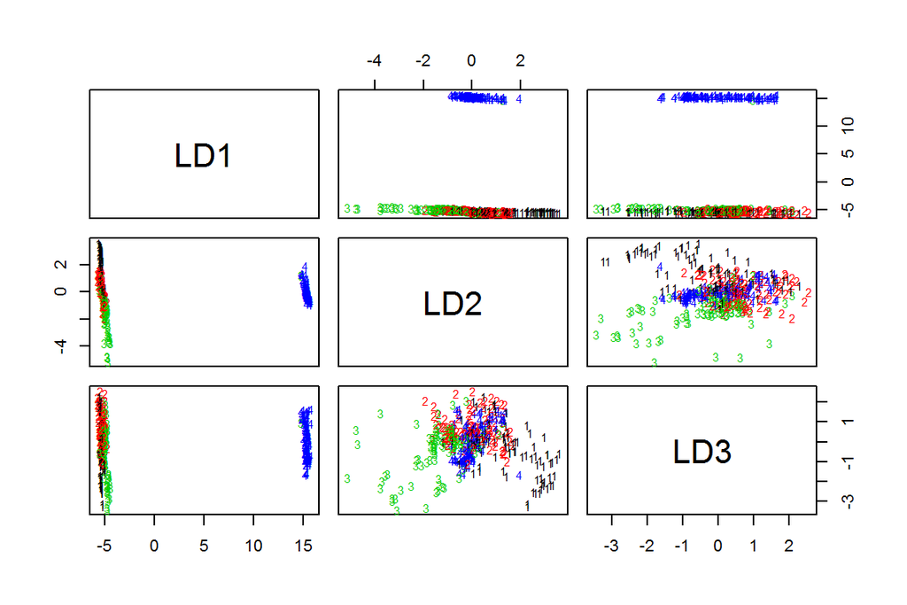

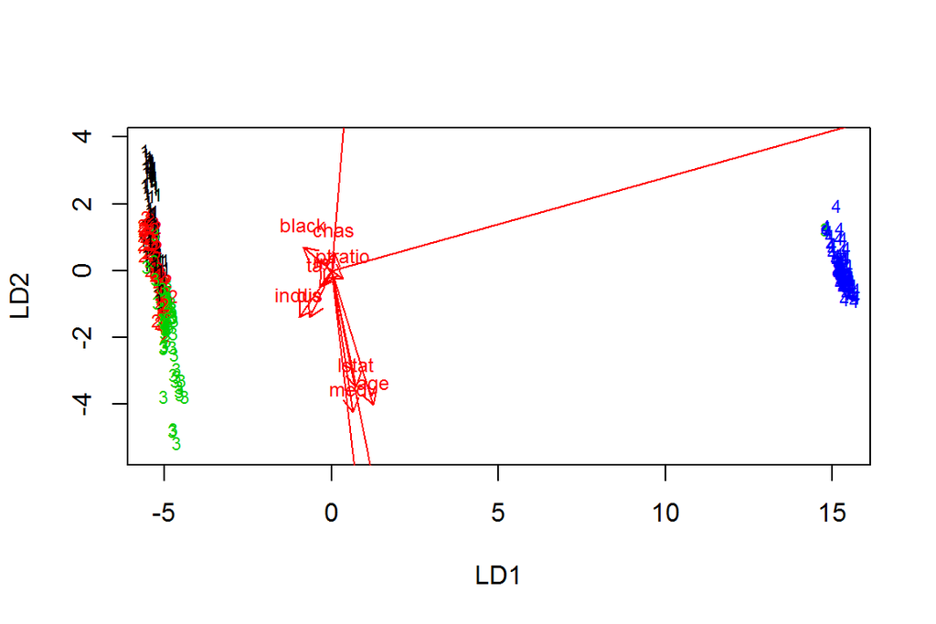

I then predicted the classes using the lda.fit and predict()-function. The cross-tabulation of the results below shows that most of the values are placed on the diagonal, i.e. then the correct value is 1 the prediction also is 1 and so on. However, there are also some in the fringes, in other words the classification is wrong and the prediction is incorrect. For example when the correct value is 1 the prediction is 2 and thus makings the prediction false. All in all, this LDA-model seems to be quite good based on the majority of the predictions being correct.

```
##        predicted
## correct  1  2  3  4
##       1 12 14  1  0
##       2  5 11  7  0
##       3  0  9 18  0
##       4  0  0  0 25
```

On the originial Boston dataset, I proceeded to perform a standardization based on the need to get comparable distances. I experimented with this, and decided to take the clusterSim-package into use and use a Normalization approach 2 that I predicted to be good for getting the same distances. I saved the Euclidian distances between the variables into the dist_eu-object and performed the k-means clustering using different numbers of clusters on the data. I concluded, calculating the total within sum of squares and drawing a plot of the result (starting from 1 and ending at the maximal number of clusters = 10), that 2 is the optimal number of clusters, since the plot seemed to go down significantly starting from the number two. The clusters are visualized below by color.

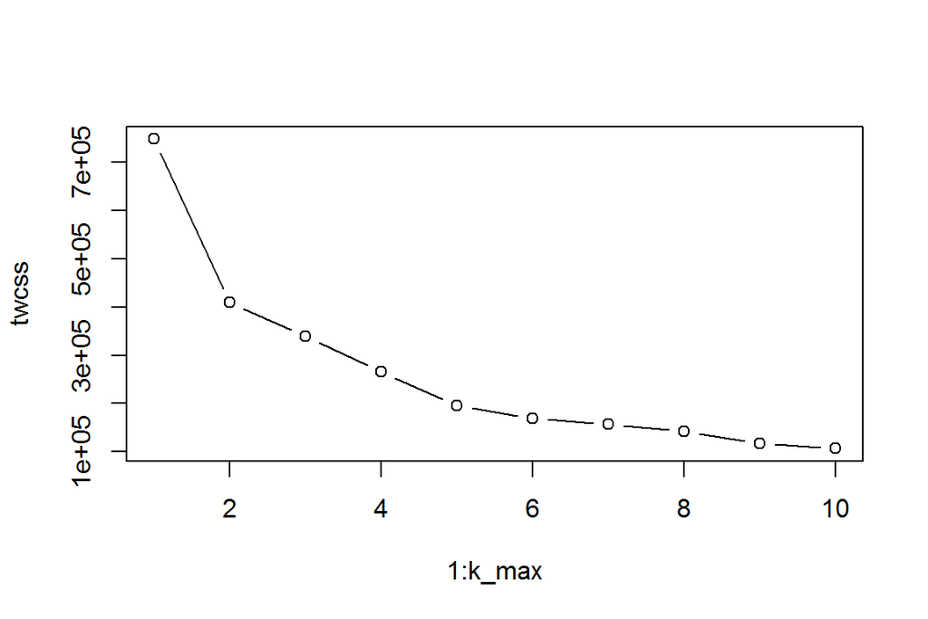

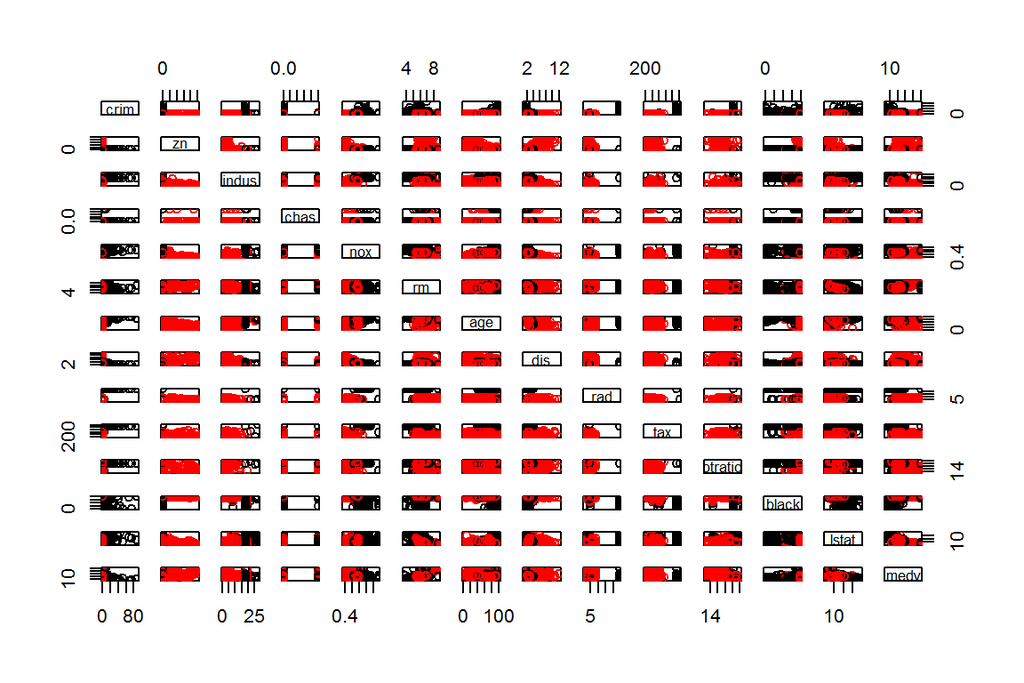

```
## Call:
## lda(km$cluster ~ ., data = Boston)
##
## Prior probabilities of groups:
##         1         2         3
## 0.1699605 0.2964427 0.5335968
##
## Group means:
##        crim          zn     indus       chas       nox       rm      age
## 1 14.410307  1.04651163 18.412791 0.18604651 0.6955465 5.889453 92.21977
## 2  3.594889  0.08333333 16.201800 0.02666667 0.6192800 6.036413 88.09867
## 3  0.184901 20.91666667  6.005333 0.05555556 0.4739507 6.548407 50.19704
##        dis       rad      tax  ptratio    black     lstat     medv
## 1 1.810314 19.941860 616.1279 19.23721 231.9315 20.426628 16.44186
## 2 2.561713 12.773333 496.2600 19.56667 369.0913 16.157333 18.00800
## 3 5.112399  4.448148 293.1185 17.58926 389.5083  8.230222 26.98667
##
## Coefficients of linear discriminants:
##                  LD1           LD2
## crim    -0.030828366  0.0869664519
## zn      -0.015314358 -0.0059126472
## indus   -0.069679715 -0.0883096847
## chas    -1.339918668  1.6001162814
## nox     -5.141704866  3.0477474546
## rm       0.391059024 -0.3225584287
## age     -0.009923483 -0.0211950792
## dis      0.090002927  0.1210279332
## rad      0.046659074 -0.0163781763
## tax     -0.005000880 -0.0001812208
## ptratio -0.139896301 -0.0984855812
## black    0.006186019 -0.0092407719
## lstat   -0.072113484  0.0424045403
## medv    -0.037617137  0.0666347548
##
## Proportion of trace:
##    LD1    LD2
## 0.8828 0.1172
```

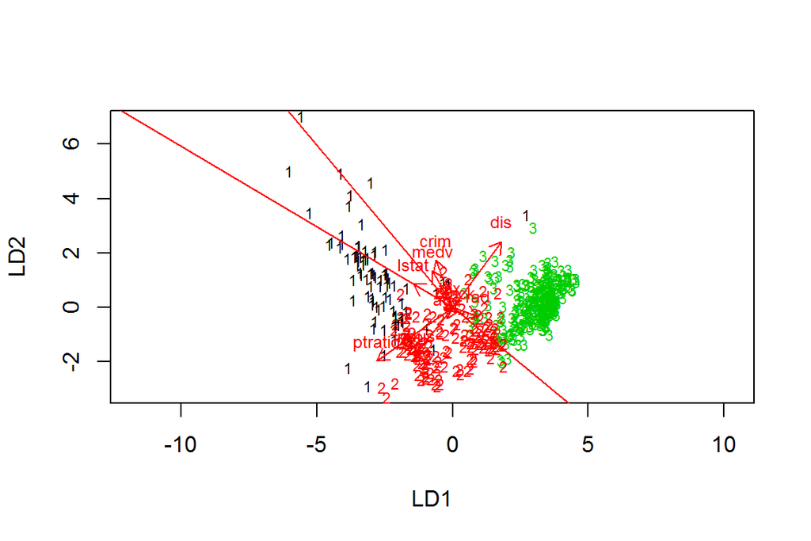

# Week 5: The Human Data

This week’s aim was to look at a joined dataset called the “human” data, which was joined from two separate datasets gii and hd in the data wrangling part of the exercise, and conduct a Principal Component Analysis (PCA) on the data. The original datasets are [Human Development Index (HDI)](http://hdr.undp.org/en/composite/HDI) and [Gender Inequality Index (GII)](http://hdr.undp.org/en/composite/GII) of 2015 of the United Nations, which focus on the different factors associated with human development and gender inequality in different countries. The datasets were joined together using country as the identificating variable and only the observations associated with countries were left in the final dataset leaving out any observations relating to geographical area rather than a specific country. In this process, the variables that were deemed irrelevant with consideration to the following analysis, were excluded, resulting in a dataset that is further explored in the upcoming chapters. During the course of the data wrangling exercise, also two additional variables were coined by calculating a ratio of some of the already existing variables to get more information out of the existing data.

To get an initial peek at the dataset at hand, we use R’s glimpse()- and summary()-functions.

```r
library(gmodels)
library(gdata)
library(dplyr) #accessed the dplyr-library
library(ggplot2) #accessed the ggplot2-library
library(readr) #accessed the readr-library
library(tidyr) #accessed tidyr-library
library(tidyverse)
library(corrplot)
library(GGally)
library(stringr)

human <- as.data.frame(read.table('human.csv'), sep="\t", header=TRUE)

glimpse(human)
```

```
## Observations: 155
## Variables: 8
## $ eduRatioFM    <dbl> 1.0072389, 0.9968288, 0.9834369, 0.9886128, 0.96...
## $ labRatioFM    <dbl> 0.8908297, 0.8189415, 0.8251001, 0.8840361, 0.82...
## $ YrsEduExp     <dbl> 17.5, 20.2, 15.8, 18.7, 17.9, 16.5, 18.6, 16.5, ...
## $ LifeExp       <dbl> 81.6, 82.4, 83.0, 80.2, 81.6, 80.9, 80.9, 79.1, ...
## $ GNIpercapita  <int> 64992, 42261, 56431, 44025, 45435, 43919, 39568,...
## $ MaternalMort  <int> 4, 6, 6, 5, 6, 7, 9, 28, 11, 8, 6, 4, 8, 4, 27, ...
## $ AdolBirth     <dbl> 7.8, 12.1, 1.9, 5.1, 6.2, 3.8, 8.2, 31.0, 14.5, ...
## $ RepParliament <dbl> 39.6, 30.5, 28.5, 38.0, 36.9, 36.9, 19.9, 19.4, ...
```

```r
summary(human)
```

```
##    eduRatioFM       labRatioFM       YrsEduExp        LifeExp
##  Min.   :0.1717   Min.   :0.1857   Min.   : 5.40   Min.   :49.00
##  1st Qu.:0.7264   1st Qu.:0.5984   1st Qu.:11.25   1st Qu.:66.30
##  Median :0.9375   Median :0.7535   Median :13.50   Median :74.20
##  Mean   :0.8529   Mean   :0.7074   Mean   :13.18   Mean   :71.65
##  3rd Qu.:0.9968   3rd Qu.:0.8535   3rd Qu.:15.20   3rd Qu.:77.25
##  Max.   :1.4967   Max.   :1.0380   Max.   :20.20   Max.   :83.50
##   GNIpercapita     MaternalMort      AdolBirth      RepParliament
##  Min.   :   581   Min.   :   1.0   Min.   :  0.60   Min.   : 0.00
##  1st Qu.:  4198   1st Qu.:  11.5   1st Qu.: 12.65   1st Qu.:12.40
##  Median : 12040   Median :  49.0   Median : 33.60   Median :19.30
##  Mean   : 17628   Mean   : 149.1   Mean   : 47.16   Mean   :20.91
##  3rd Qu.: 24512   3rd Qu.: 190.0   3rd Qu.: 71.95   3rd Qu.:27.95
##  Max.   :123124   Max.   :1100.0   Max.   :204.80   Max.   :57.50
```

Interpreting the above table, the dataset has eight variables and 155 observations (for 155 countries). The variables (renamed by myself in the data wrangling exercise) included in this dataset are:

eduRatioFM = Share of female population with secondary education / Share of male population with secondary education

labRatioFM = Share of female population that participates in labour force / Share of male population that participates in labour force

YrsEduExp = Expected years of education

LifeExp = Life expectancy at birth

GNIpercapita = Gross national income (GNI) per capita (dollars, purchasing power parity)

MaternalMort = Maternal mortality rate

AdolBirth = Adolescent birth rate

RepParliament = Share of female representatives in the national parliament.

The summary of the dataset informs about the range of the variables, the median, quartiles and minimum and maximum values. By looking at the table it is clear to see that some of the max-values are extremely high compared to the median, which could indicate that there are some outliers or exceptional observations in the data.

The relationships between the variables in this dataset can be visualized by the ggpairs()-function, which demonstrates the scatter plots and correlation factors of the variables:

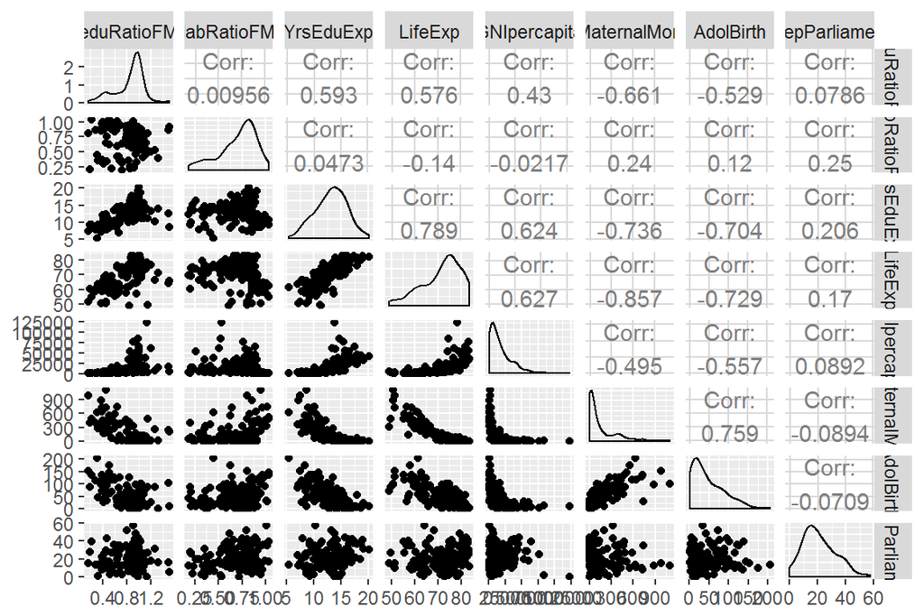

```r
ggpairs(human)
```

From the matrix above, it can be concluded that almost all of the variables’ distributions are relatively skewed, i.e. most of the values are in either end of the scale. However, for instance the gender ratio of population with secondary education and expected years in education variables seem to be quite close to being normally distributed, at least they peak in the middle of their range. It can also be noted that there indeed is significant correlation between different variables, going from -0,857 negative correlation between Maternal mortality and Life expectancy up to 0,789 positive correlation between Life expectancy and Expected years of education. This, in turn, goes well together with the intuition one might have about the relationship between these particular variables: a high maternal mortality rate is in negative correlation with life expectancy, i.e. when maternal mortality increases, life expectancy in turn decreases, and when life expectancy increases, the positive correlation with expected years of education indicates that also the values of the YrsEduExp-variable increase (no causality indicated, of course). Also other values in this chart seem quite remarkable, but the anove table isn’t the most auspicious for the full interpretation of them, for which reason it is justifiable to draw a correlation matrix with visually helpful dots indicating the correlation between the variables and colours telling wether the correlation is positive or negative.

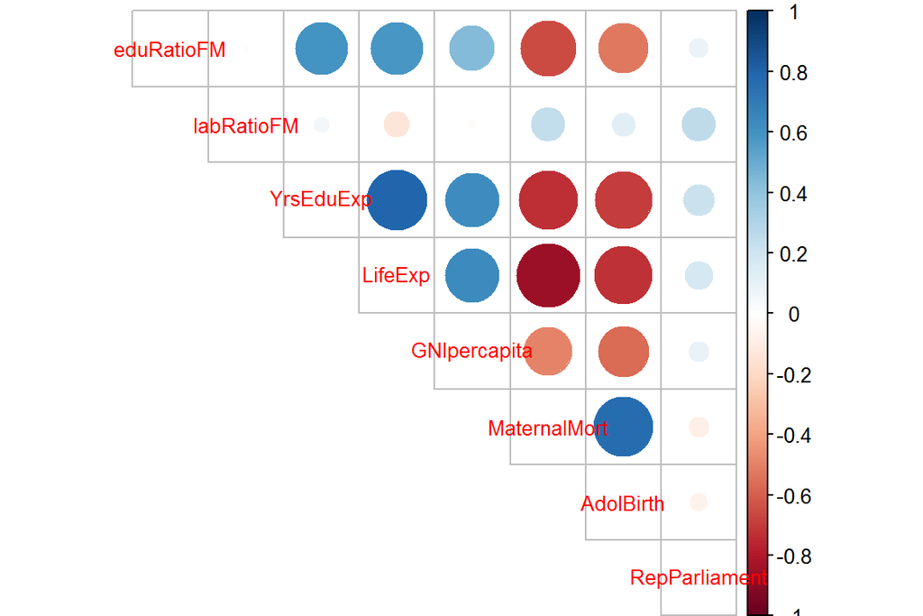

```r
corrplot(round(cor(human), digits = 2), method = "circle", type = "upper", tl.pos = "d", tl.cex = 0.8)
```

Now that the correlations can be determined by the colours and sizes of the dots in the matrix, it is easier to see which variables are in which kind of correlation with each other. Instantly we see that the aforementioned correlations (expected years of education with life expectancy, and maternal mortality with life expectancy) are the strongest: marked with big dark blue and dark red dots. Looking at this table it is also more clear to see that also maternal mortality and adolescent birth rate are in positive correlation, whereas expected years of education is in negative correlation with both maternal mortality rate and adolescent birth. Also both expected years in education and life expectancy are in positive correlation with Gross national income per capita, which is quite intuitive.

## PCA of the Human data

A Principal Component Analysis (abbreviated as PCA) can be conducted on the dataset to lower its dimensionality using the singular value decomposition (SVD) method. The SVD literally decomposes a matrix and produces a product of smaller matrices, which brings out the most important components, and in statistics, PCA aims to do exactly that. It represents the data at hand in two dimensions with respect to Principal components - the components which explain different proportions of variance of the original variables, or in other words, features. The first Principal component always explains the largest proportion of variance along the features, and the importance of the PC is relative to the order in which it is represented in the PCA: for example, PC2 explains the second largest proportion of variance and PC3 the third largest and so on. Usually only two principal components explain the most significant amount of variance, hece the two-dimensionality of the PCA and the resulting biplot (bi = two) with arrows representing the correlation between the variables with each other and with the two PCs. Consequently, the Principal components are also uncorrelated, which means that the angle between them is 90 degrees (which corresponds to a 0 correlation).

According to instructions, the PCA is first done on the non-standardised dataset for learning purposes - we know it would be essential to standardize the dataset before attempting PCA on it, but it is useful to see the results if we do not do so. First we create a pca_human -object into which we save the PCA with prcomp()-function and then print the summary (s_nonst) of it.

```r
pca_human <- prcomp(human)
s_nonst <- summary(pca_human)
s_nonst
```

```
## Importance of components:
##                              PC1      PC2   PC3   PC4   PC5   PC6    PC7
## Standard deviation     1.854e+04 185.5219 25.19 11.45 3.766 1.566 0.1912
## Proportion of Variance 9.999e-01   0.0001  0.00  0.00 0.000 0.000 0.0000
## Cumulative Proportion  9.999e-01   1.0000  1.00  1.00 1.000 1.000 1.0000
##                           PC8
## Standard deviation     0.1591
## Proportion of Variance 0.0000
## Cumulative Proportion  1.0000
```

The problem with this initial approach without standardization is, as shown in the summary, that PC1 which is the first Principal Component, explains nearly all of the variance in contrast to the other PCs with significantly lower - essentially zero - proportions of variance. The plot of the precluding analysis is a bit strange and further indicates there is a problem with this approach:

[output not shown]

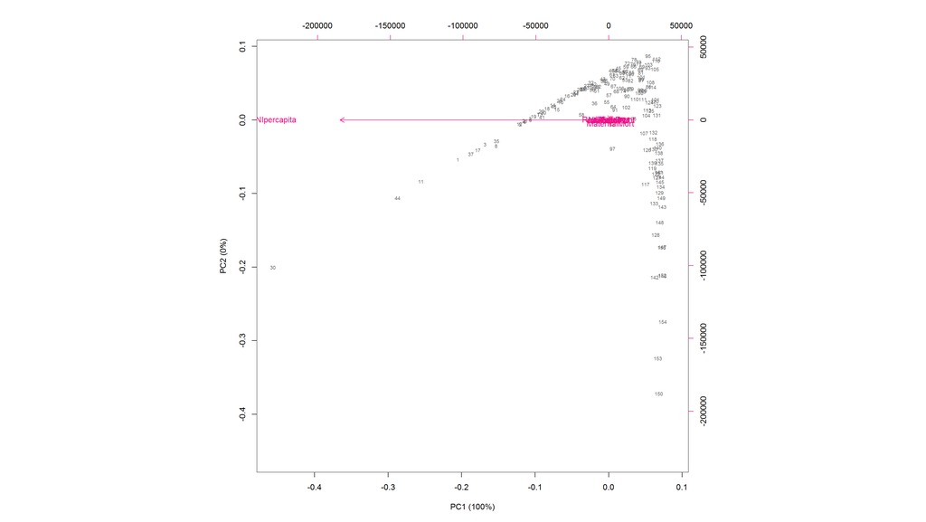

```r
pr_snonst <- round(100*s_nonst$importance[2, ], digits = 1)
pc_snonst_lab <- paste0(names(pr_snonst), " (", pr_snonst, "%)")
biplot(pca_human, choices = 1:2, cex = c(0.6, 1), col = c("grey40", "deeppink2"), xlab = pc_snonst_lab[1], ylab = pc_snonst_lab[2])
```

The picture is not very useful; in addition, there seems to be a problem drawing the arrows (according to the warning messages: “zero-length arrow is of indeterminate angle and so skipped”). Also the labels created from the percentages of variance are quite nonsensical - PC2(0%) and PC1(100%) which is true in this PCA but quite irrational for any kind of analysis. The result is indeed due to the skewed distributions of the variables - almost none of them were close to being normally distributed - so the differing variances led PCA to “think” that those variables with larger variance are also more important.

Because PCA is impacted by the scaling of the features, it is, as instructed, more than useful to move on to use a different approach. By standardizing the dataset with the scale()-function used last week, we get the result that PCA can interpret more accordingly.

```r
human_st <- scale(human)
pca_st <- prcomp(human_st)
s_st <- summary(pca_st)
s_st
```

```
## Importance of components:
##                           PC1    PC2     PC3     PC4     PC5     PC6
## Standard deviation     2.0708 1.1397 0.87505 0.77886 0.66196 0.53631
## Proportion of Variance 0.5361 0.1624 0.09571 0.07583 0.05477 0.03595
## Cumulative Proportion  0.5361 0.6984 0.79413 0.86996 0.92473 0.96069
##                            PC7     PC8
## Standard deviation     0.45900 0.32224
## Proportion of Variance 0.02634 0.01298
## Cumulative Proportion  0.98702 1.00000
```

As we can see from the row of Proportion of Variance, the results differ from the previous approach quite significantly. Now each of the PCAs explains some proportion of the variance - the first, PC1, having the largest proportion of variance in this case, too - and none of the PCs get a zero proportion. The rationality of this approach can be seen more efficiently by drawing the picture:

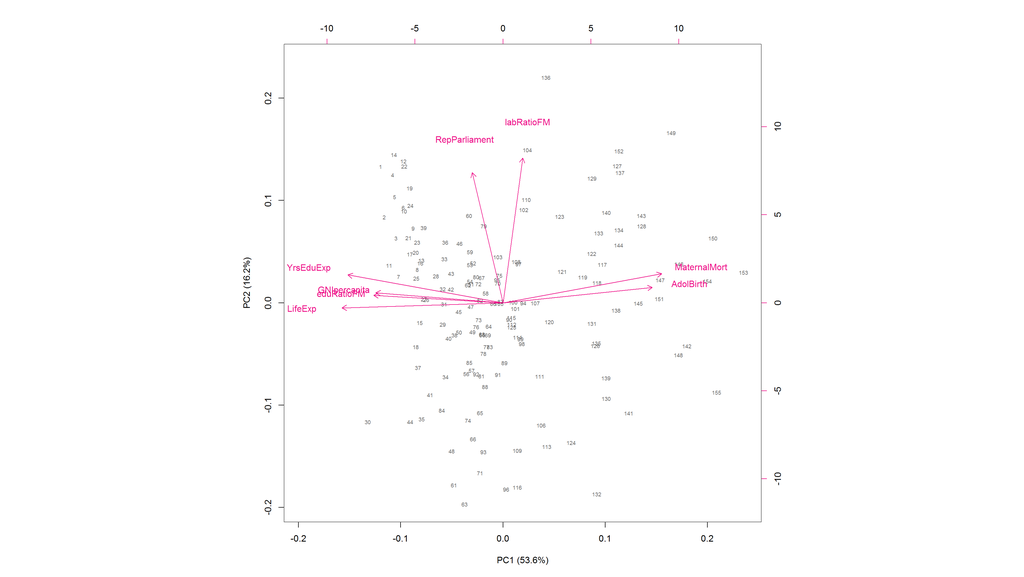

```r
pr_sst <- round(100*s_st$importance[2, ], digits = 1)
pc_sst_lab <- paste0(names(pr_sst), " (", pr_sst, "%)")
biplot(pca_st, choices = 1:2, cex = c(0.6, 1), col = c("grey40", "deeppink2"), xlab = pc_sst_lab[1], ylab = pc_sst_lab[2])
```

The proportions of variance as labels make more sense now, and there are no warnings regarding the drawing of the arrows. Also the picture looks clearer, the arrows are headed to different directions and the result seems interesting enough for some analysis to be executed.

## The analysis of the PCA

As stated before, the biplot and the summary table indicate much clearer results now. It seems that the first principal component explains a proportion of 53.6% of the total variance of the total of eight variables whereas the second principal component explains 16.2% of all the variance.

What is more, we can also interpret the angle between a given variable with another as the correlation between the two. It would be useful to draw a correlation matrix now to see how the picture corresponds with the correlation matrix.

```r
cor_matrix<-cor(human_st)

# print the correlation matrix
cor_matrix <- cor_matrix%>%round(2)
cor_matrix
```

```
##               eduRatioFM labRatioFM YrsEduExp LifeExp GNIpercapita
## eduRatioFM          1.00       0.01      0.59    0.58         0.43
## labRatioFM          0.01       1.00      0.05   -0.14        -0.02
## YrsEduExp           0.59       0.05      1.00    0.79         0.62
## LifeExp             0.58      -0.14      0.79    1.00         0.63
## GNIpercapita        0.43      -0.02      0.62    0.63         1.00
## MaternalMort       -0.66       0.24     -0.74   -0.86        -0.50
## AdolBirth          -0.53       0.12     -0.70   -0.73        -0.56
## RepParliament       0.08       0.25      0.21    0.17         0.09
##               MaternalMort AdolBirth RepParliament
## eduRatioFM           -0.66     -0.53          0.08
## labRatioFM            0.24      0.12          0.25
## YrsEduExp            -0.74     -0.70          0.21
## LifeExp              -0.86     -0.73          0.17
## GNIpercapita         -0.50     -0.56          0.09
## MaternalMort          1.00      0.76         -0.09
## AdolBirth             0.76      1.00         -0.07
## RepParliament        -0.09     -0.07          1.00
```

From the correlation matrix above and the biplot printed earlier, we can indeed see that the correlations between the variables are shown in the biplot. For example, the correlation between maternal mortality and adolescent birth is strongly positie, 0,76 as read from the correlation matrix, and from the biplot we can see that in between the arrows there is only a small angle. As opposed to for example expected years of education and maternal morality, which have a strong negative correlation, that of -0,74, the biplot also indicates that the corresponding arrows point to the opposite directions.

The biplot also shows, which kind of features contribute to PC1 and PC2. The variables in relation to PC1 are mostly variables that describe wealth - or lack thereof - for example, the GNIpercapita, maternal mortality etc. They have less to do with gender inequality or equality, than those contributing to PC2 (labRatioFM and RepParliament, which have to do with gender representation and participation in Labour movement and Parliament, the first being ratio of female participation in the labour force and the latter being the proportion of female MPs represented in the Parliament). We could conclude that PC1 is a poverty-component, which explains the most variance, whereas PC2 has to do with equality values and explains only some of the total variance, and the correlation between these two is nonexistent (zero). The equality is affected by two main components already mentioned, and the poverty component or PC1 is impacted by maternal mortality and adolescent birth in an increasing manner, and for example expected years in education, GNI per capita and life expectancy in a decreasing manner. This is also very intuitive, however a very over-simplifying interpretation and I’m not sure whether it has any grounds, but it is nice to play with ideas.

# The Tea data

The final part of the instructions was to conduct a Multiple Correspondence Analysis (MCA) for [the Tea dataset already installed in the FactoMineR library in R](https://cran.r-project.org/web/packages/FactoMineR/FactoMineR.pdf). It is described as concerning a questionnaire on tea, where 300 individuals were asked about their tea drinking habits, product’s perception and personal details with the total of 34 questions. It is also stated in the description that Tea is a “data frame with 300 rows and 36 columns. Rows represent the individuals, columns represent the different questions. The first 18 questions are active ones, the 19th is a supplementary quantitative variable (the age) and the last variables are supplementary categorical variables”. Let’s look at the data:

```r
library(FactoMineR)

data("tea")
glimpse(tea)
```

```
## Observations: 300
## Variables: 36
## $ breakfast        <fctr> breakfast, breakfast, Not.breakfast, Not.bre...
## $ tea.time         <fctr> Not.tea time, Not.tea time, tea time, Not.te...
## $ evening          <fctr> Not.evening, Not.evening, evening, Not.eveni...
## $ lunch            <fctr> Not.lunch, Not.lunch, Not.lunch, Not.lunch, ...
## $ dinner           <fctr> Not.dinner, Not.dinner, dinner, dinner, Not....
## $ always           <fctr> Not.always, Not.always, Not.always, Not.alwa...
## $ home             <fctr> home, home, home, home, home, home, home, ho...
## $ work             <fctr> Not.work, Not.work, work, Not.work, Not.work...
## $ tearoom          <fctr> Not.tearoom, Not.tearoom, Not.tearoom, Not.t...
## $ friends          <fctr> Not.friends, Not.friends, friends, Not.frien...
## $ resto            <fctr> Not.resto, Not.resto, resto, Not.resto, Not....
## $ pub              <fctr> Not.pub, Not.pub, Not.pub, Not.pub, Not.pub,...
## $ Tea              <fctr> black, black, Earl Grey, Earl Grey, Earl Gre...
```

[output cut: 23 more lines]

First off, we can see the dimensions of the data: as mentioned before, the data has 300 observations and 36 variables. What we can also see, is that all of the variables (age excluded) are factor-type, categorical variables (most even binary), which drives us towards MCA rather than PCA.

I decided to keep the variables spirituality, tearoom, sophisticated, sugar, healthy, slimming, to see how similar the associations about tea are and which go hand in hand just for fun. The variables describe the kind of images the respondents have about tea, whether they associate tea drinking with spirituality or not, whether they go to special tea rooms or not, whether they consider tea drinking sophisticated, do they drink their tea with sugar and do they consider tea drinking healthy and slimming or not. First I excluded all other variables from the dataset and was left with only six remaining variables, a dataset I called “tea_associations”.

```r
keep_columns <- c("spirituality", "tearoom", "sophisticated", "sugar", "healthy", "slimming")

# select the 'keep_columns' to create a new dataset
tea_associations <- dplyr::select(tea, one_of(keep_columns))

# look at the summaries and structure of the data
summary(tea_associations)
```

```
##            spirituality        tearoom              sophisticated
##  Not.spirituality:206   Not.tearoom:242   Not.sophisticated: 85
##  spirituality    : 94   tearoom    : 58   sophisticated    :215
##       sugar            healthy           slimming
##  No.sugar:155   healthy    :210   No.slimming:255
##  sugar   :145   Not.healthy: 90   slimming   : 45
```

```r
str(tea_associations)
```

```
## 'data.frame':    300 obs. of  6 variables:
##  $ spirituality : Factor w/ 2 levels "Not.spirituality",..: 1 1 1 2 2 1 1 1 1 1 ...
##  $ tearoom      : Factor w/ 2 levels "Not.tearoom",..: 1 1 1 1 1 1 1 1 1 2 ...
##  $ sophisticated: Factor w/ 2 levels "Not.sophisticated",..: 1 1 1 2 1 1 1 2 2 1 ...
##  $ sugar        : Factor w/ 2 levels "No.sugar","sugar": 2 1 1 2 1 1 1 1 1 1 ...
##  $ healthy      : Factor w/ 2 levels "healthy","Not.healthy": 1 1 1 1 2 1 1 1 2 1 ...
##  $ slimming     : Factor w/ 2 levels "No.slimming",..: 1 1 1 1 1 1 1 1 1 1 ...
```

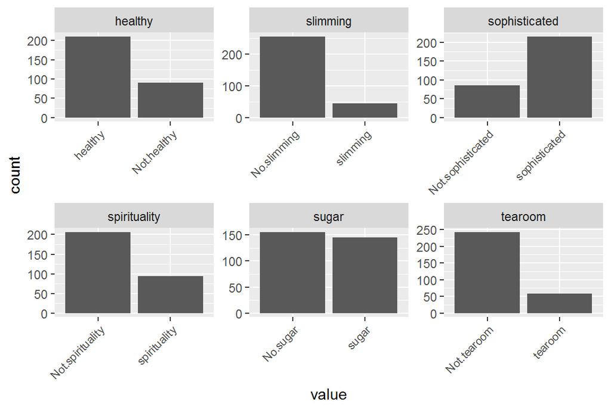

```r
# visualize the dataset
gather(tea_associations) %>% ggplot(aes(value)) + facet_wrap("key", scales = "free") + geom_bar() + theme(axis.text.x = element_text(angle = 45, hjust = 1, size = 8))
```

The barplots of the variables can be viewed from above. They indicate that the majority of drinkers consider tea to be healthy vs not healthy and that the slimming option in the questionnaire was less popular than not slimming. Moreover, tea was more often considered sophisticated than not, and less often associated with spirituality than not. The sugar addition was relatively evenly distributed, as opposed to the tearoom/ not tearoom distribution: most respondents chose the not tearoom option.

Next, let’s look at the Multiple Correspondence Analysis of tea_associations.

```r
# multiple correspondence analysis
mca <- MCA(tea_associations, graph = FALSE)

# summary of the model

summary(mca)
```

```
##
## Call:
## MCA(X = tea_associations, graph = FALSE)
##
##
## Eigenvalues
##                        Dim.1   Dim.2   Dim.3   Dim.4   Dim.5   Dim.6
## Variance               0.212   0.197   0.178   0.143   0.140   0.129
## % of var.             21.183  19.743  17.836  14.323  13.982  12.933
## Cumulative % of var.  21.183  40.926  58.762  73.085  87.067 100.000
##
## Individuals (the 10 first)
##                      Dim.1    ctr   cos2    Dim.2    ctr   cos2    Dim.3
## 1                 | -0.647  0.658  0.512 | -0.404  0.276  0.200 |  0.115
## 2                 | -0.343  0.185  0.148 | -0.502  0.426  0.318 | -0.431
## 3                 | -0.343  0.185  0.148 | -0.502  0.426  0.318 | -0.431
## 4                 |  0.150  0.035  0.030 |  0.157  0.042  0.033 |  0.751
## 5                 | -0.392  0.242  0.110 |  0.229  0.088  0.037 |  0.046
## 6                 | -0.343  0.185  0.148 | -0.502  0.426  0.318 | -0.431
## 7                 | -0.343  0.185  0.148 | -0.502  0.426  0.318 | -0.431
## 8                 |  0.158  0.039  0.057 | -0.190  0.061  0.082 | -0.359
## 9                 | -0.187  0.055  0.046 |  0.292  0.144  0.113 | -0.446
## 10                |  0.032  0.002  0.001 | -0.005  0.000  0.000 | -0.758
##                      ctr   cos2
## 1                  0.025  0.016 |
## 2                  0.347  0.234 |
## 3                  0.347  0.234 |
## 4                  1.054  0.752 |
## 5                  0.004  0.001 |
## 6                  0.347  0.234 |
## 7                  0.347  0.234 |
## 8                  0.241  0.293 |
## 9                  0.372  0.263 |
## 10                 1.074  0.397 |
##
## Categories (the 10 first)
##                       Dim.1     ctr    cos2  v.test     Dim.2     ctr
## Not.spirituality  |  -0.256   3.537   0.143  -6.550 |  -0.208   2.502
## spirituality      |   0.561   7.751   0.143   6.550 |   0.455   5.483
## Not.tearoom       |  -0.200   2.544   0.167  -7.072 |  -0.256   4.478
```

[output cut: 12 more lines]

```
## Not.sophisticated   0.141  -6.487 |  -0.131   0.458   0.007  -1.429 |
## sophisticated       0.141   6.487 |   0.052   0.181   0.007   1.429 |
## No.sugar            0.017  -2.263 |  -0.669  21.596   0.478 -11.957 |
## sugar               0.017   2.263 |   0.715  23.085   0.478  11.957 |
## healthy             0.347 -10.189 |   0.066   0.287   0.010   1.751 |
## Not.healthy         0.347  10.189 |  -0.155   0.670   0.010  -1.751 |
##
## Categorical variables (eta2)
##                     Dim.1 Dim.2 Dim.3
## spirituality      | 0.143 0.095 0.439 |
## tearoom           | 0.167 0.274 0.107 |
## sophisticated     | 0.389 0.141 0.007 |
## sugar             | 0.175 0.017 0.478 |
## healthy           | 0.190 0.347 0.010 |
## slimming          | 0.206 0.311 0.029 |
```

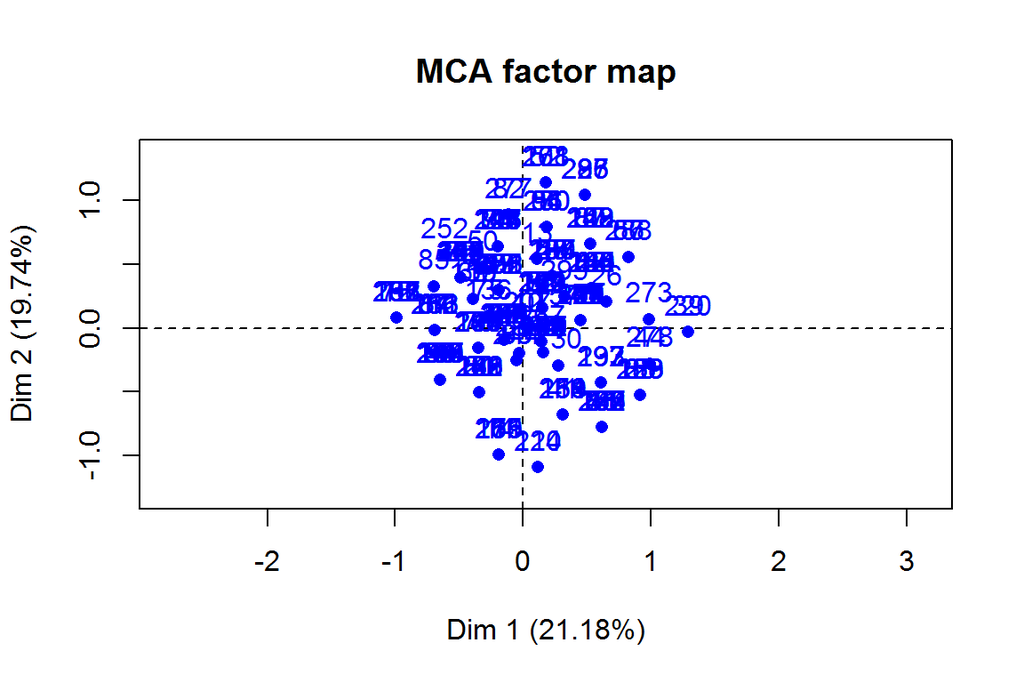

```r
# visualize MCA
plot(mca, invisible=c("var"))
```

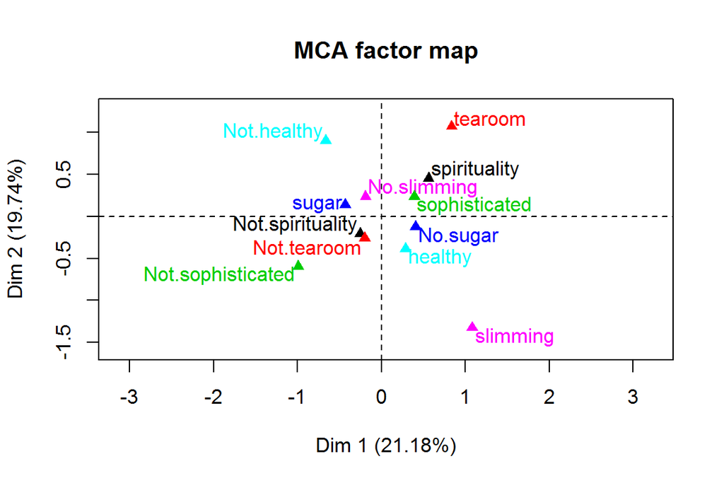

```r
plot(mca, invisible=c("ind"), habillage = "quali")
```

From the summary we can see the percentages of variance by dimension under the eigenvalues-label. The percentage is not very high on the first dimension but it is the one that explains the most of the variability, of course. Then, from the individuals table we can see the values for the ten first individuals, which include the individuals contribution on the dimension (in percents) and the cos2 which is the squared correlation. From the categories part of the table we can see the coordinates of each variable, the cos2 similarly as for individuals and also a v-test value, which tells if the coordinate is significantly different from zero (the v-test follows normal distribution so if the value is below or above 1,96, the variable differs from zero significantly). The table indicates that almost all of the variables differ from zero.

In the categorical values a close to one value indicates a strong correlation. The values are co2 values, and we can see that not many of the values have strong correlations, since the values are closer to zero than to 1.

The individuals plot doesn’t tell us much; it just shows the individuals’ distribution on the Dimensions map. The variable map is much more interesting. From it we can read that for example spirituality and sophisticated, and in turn, no sugar and healthy are within a small distance of each other, which tells us there is a connection or correlation between the pairs, whereas the opposing values are on the other end and not so close to each other. Slimming and not healthy are outside of all the values, which indicates they do not have a connection with the other variables and are different than all the other ones. Also tearoom could be included in this group.